# Reuter et al. 2025 Analysis Version 2

Manuela Reuter

2025-12-17

# This is the code used to analyze and visualize the data used in the manuscript of Reuter et al. 2025

# Set working directory

```r
setwd("/Users/spagnuolo/Desktop/Reuter et el. 2025_final_new/Raw_data/Data_sets_Phage_titers")
```

# Load required packages

```r
## General packages required for analysis of all experiments
### Data organization and structuring
library(dplyr)
library(tidyr)
library(car)
library(tidyverse)
```

```r
### Data visualization
library(ggplot2)
library(gridExtra)
library(ggthemes)
library(plotrix)
library(scales) # for trans_beaks when axis is log-transformed
library(ggpubr)

# Experiment 3: Adsorption constant analysis
library(multcomp) # Pairwise comparison
library(lme4) # Linear mixed model
# Experiment 4: Images analysis plaques
library (viridis)
# Experiment 6: Decay analysis
library(stringr)
```

# Experiment 1: 3-hour transfer regime

Code was used to monitor MOI input for each transfer.

**READ ME** *Specification of columns in data set*

- **Transfer** (T): Individual three-hour transfers
- **Line (L)**: 5 selection lines started at the beginning of the experiment from five individual large plaques of ancestral, large-plaque-forming phage PhiX174
- **CFU**: colony-forming units of E. coli C after 2 hours of growth to exponential phase. CFU count of T3 (644 CFU) was acquired by counting a quarter of the plate (161 CFU), which was multiplied by a factor 4
- **Dilution_CFU**: plating dilution used to plate the colonies counted; 100 µl of this dilution was plated unless stated otherwise
- **PFU**: Plaque-forming units counted on plaque assay plate. Plaque assays were done for the phage lysate extracted after each transfer by chloroform extraction
- **Dilution_PFU**: plating dilution used to plate phage plaques. 100 µl of this dilution was plated unless stated otherwise

## **Visualize Bacteria and Phage concentrations for each 3-h transfer**

## Load data set

```r
df<-read.csv("experiment_1_3_h_transfers.csv")

# df should have 28 observations of 6 variables
```

## Checking data set

```r
str(df) # structure of the columns
```

```
## 'data.frame':    28 obs. of  6 variables:
##  $ Transfer    : chr  "T1" "T1" "T1" "T1" ...
##  $ Line        : chr  "L1" "L2" "L3" "L4" ...
##  $ CFU         : int  76 76 76 76 76 98 98 98 98 98 ...
##  $ Dilution_CFU: num  1e+05 1e+05 1e+05 1e+05 1e+05 1e+05 1e+05 1e+05 1e+05 1e+05 ...
##  $ PFU         : int  120 21 238 88 44 21 26 89 19 132 ...
##  $ Dilution_PFU: num  1e+07 1e+07 1e+07 1e+07 1e+07 1e+07 1e+07 1e+07 1e+07 1e+07 ...
```

```r
summary(df) # summary of the columns
```

```
##    Transfer             Line                CFU         Dilution_CFU
##  Length:28          Length:28          Min.   : 76.0   Min.   : 10000
##  Class :character   Class :character   1st Qu.: 98.0   1st Qu.:100000
##  Mode  :character   Mode  :character   Median :150.0   Median :100000
##                                        Mean   :248.3   Mean   : 83929
##                                        3rd Qu.:373.0   3rd Qu.:100000
##                                        Max.   :644.0   Max.   :100000
##       PFU          Dilution_PFU
##  Min.   : 19.00   Min.   : 10000000
##  1st Qu.: 30.50   1st Qu.: 10000000
##  Median : 63.50   Median : 10000000
##  Mean   : 66.82   Mean   : 19642857
##  3rd Qu.: 87.25   3rd Qu.: 10000000
##  Max.   :238.00   Max.   :100000000
```

```r
# Turn Transfer and Line into factors
df$Transfer=as.factor(df$Transfer)
df$Line=as.factor(df$Line)
```

## Calculate CFU per ml and PFU per ml

```r
# Calculate CFU per ml by multiplying CFU counts and Dilution factor and multiply by an additional factor 10 to get CFU per ml because 100 µl of the plating dilution "Dilution_CFU" was used for plating
df$CFU_ml=df$CFU*df$Dilution_CFU*10

# Calculate PFU per ml by multiplying PFU counts and Dilution factor and multiply by an additional factor 10 to get PFU per ml because 100 µl of the plating dilution "Dilution_PFU" was used for the plaque assay
df$PFU_ml=df$PFU*df$Dilution_PFU*10
```

## Visualize bacteria and phage concentration for each transfer using a dotplot

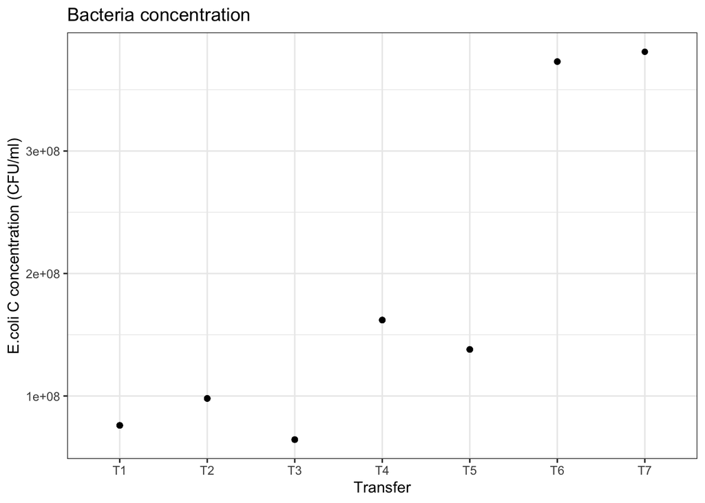

```r
# Bacteria concentration
a=ggplot(df,aes(Transfer,CFU_ml))+
  geom_point()+ # dot plot
  xlab("Transfer")+ # label of x-axis
  ylab("E.coli C concentration (CFU/ml)")+ # label of y-axis
    ggtitle("Bacteria concentration")+ # plot title
theme_bw() #plot layout
a
```

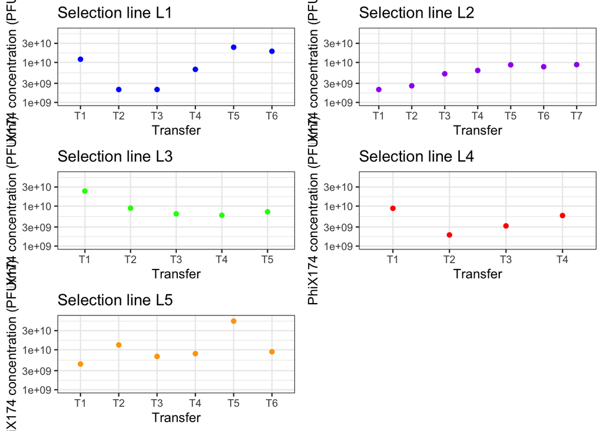

```r
# Virus concentration for each selection line separately until first small plaques were detected (comments on plot b also apply to plots c-f)
## Selection line 1
b=ggplot(df[df$Line=="L1",],aes(Transfer,PFU_ml))+
  geom_point(color="blue")+ # dot plot
  scale_y_continuous(trans="log10", limits=c(1e+09,6e+010))+ # log transformed y-axis
  xlab("Transfer")+ # label of x-axis
  ylab("PhiX174 concentration (PFU/ml)")+ #label of y-axis
  ggtitle("Selection line L1")+ # plot title
theme_bw() # plot layout

## Selection line 2
c=ggplot(df[df$Line=="L2",],aes(Transfer,PFU_ml))+
  geom_point(color="purple")+
  scale_y_continuous(trans="log10", limits=c(1e+09,6e+010))+
  xlab("Transfer")+
  ylab("PhiX174 concentration (PFU/ml)")+
  ggtitle("Selection line L2")+
  theme_bw()

## Selection line 3
d=ggplot(df[df$Line=="L3",],aes(Transfer,PFU_ml))+
  geom_point(color="green")+
  scale_y_continuous(trans="log10", limits=c(1e+09,6e+010))+
  xlab("Transfer")+
  ylab("PhiX174 concentration (PFU/ml)")+
  ggtitle("Selection line L3")+
  theme_bw()

## Selection line 4
e=ggplot(df[df$Line=="L4",],aes(Transfer,PFU_ml))+
  geom_point(color="red")+
  scale_y_continuous(trans="log10", limits=c(1e+09,6e+10))+
  xlab("Transfer")+
  ylab("PhiX174 concentration (PFU/ml)")+
  ggtitle("Selection line L4")+
  theme_bw()

## Selection line 5
f=ggplot(df[df$Line=="L5",],aes(Transfer,PFU_ml))+
  geom_point(color="orange")+
  scale_y_continuous(trans="log10", limits=c(1e+09,6e+010))+
  xlab("Transfer")+
  ylab("PhiX174 concentration (PFU/ml)")+
  ggtitle("Selection line L5")+
  theme_bw()

# Combine phage concentration plots for all selection lines in one plot
grid.arrange(b,c,d,e,f)
```

# Experiment 1: Transfers required to observe first de-novo small plaque mutants and their frequency

Code used to generate Fig. S5A in the manuscript

**READ ME** *Specification of columns in data set*

- **Line (L)**: Five selection lines started at the beginning of the experiment from five individual large plaques of ancestral PhiX174
- **Genotype**: Genotype of the small plaque mutant isolated from the 3-h regime, with the single-point mutation indicated as F[for F protein] and in the brackets the mutation in the protein with old amino acid, amino acid position, and new amino acid
- **Transfer_number** (T): Number of 3-h transfers required to isolate one isogenic, heritable small plaque
- **Total_PFU_ml**: Total Phage concentration in PFU per ml for the transfer at which the first small plaques were observed. Column corresponds to the PFU_ml column of data set *“experiment_1_3_h_transfers.csv”* (see above) was used for the first transfer at which the first small plaque mutant could be isolated from a plaque assay plate - For Line L1 the first small plaques were isolated after transfer T6 - For Line L2 the first small plaques were isolated after transfer T7 - For Line L3 the first small plaques were isolated after transfer T5 - For Line L4 the first small plaques were isolated after transfer T4 - For Line L5 the first small plaques were isolated after transfer T6
- **Small_PFU_ml**: Estimated concentration of small plaques of the “Total_PFU_ml”

## Load data set

```r
# Create data frame with number of transfers required to get first small plaques
df=read.csv("experiment_1_3_h_transfers_small_plaque_frequency.csv")

# df should have 5 observations of 5 variables
```

## Checking data set

```r
str(df) #structure of the dataset
```

```
## 'data.frame':    5 obs. of  5 variables:
##  $ Line           : chr  "L1" "L2" "L3" "L4" ...
##  $ Genotype       : chr  "F(G322D)" "F(G322D)" "F(M213I)" "F(S427*)" ...
##  $ Transfer_number: int  6 7 5 4 6
##  $ Total_PFU_ml   : num  1.9e+10 8.8e+09 7.2e+09 5.8e+09 8.9e+09
##  $ Small_PFU_ml   : num  1e+09 1e+08 1e+08 1e+08 1e+08
```

```r
# Convert Line and Genotype into factors
df$Genotype=as.factor(df$Genotype)
df$Line=as.factor(df$Line)
```

## Calculate frequency in % of small plaques compared to the total phage concentration

```r
# Create a new column for the frequency of small plaques in %
df$Frequency=NA

# Calculate the frequency in %
df$Frequency=(df$Small_PFU_ml)/(df$Total_PFU_ml*0.01)

# show frequencies
print(df$Frequency)
```

```
## [1] 5.263158 1.136364 1.388889 1.724138 1.123596
```

## Visualize results using a barplot (Fig. S5A)

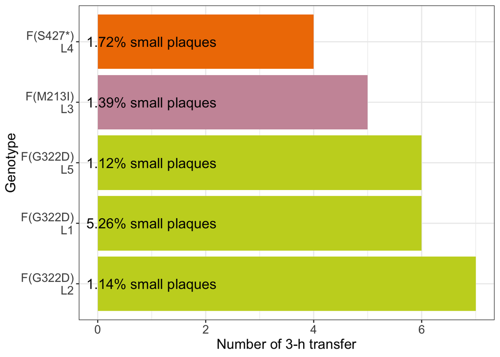

```r
# Code to get the x-ticks in two lines including selection line AND genotype
addline_format <- function(x,...){
    gsub('\\s','\n',x)
}


# Visualize results
x=ggplot(df,aes(x=reorder(Line, -Transfer_number),y=Transfer_number, group=Genotype, fill=Genotype))+
  geom_col()+ # bar chart
  coord_flip()+ # flip x and y axis
  scale_fill_manual(values=c("#c6d325","#CC97A7", "#ef7c00"))+ # fill colors based on genotype
  scale_x_discrete(limits=c("L2","L1","L5","L3","L4"),
                   labels=addline_format(c("F(G322D) L2","F(G322D) L1","F(G322D) L5","F(M213I) L3","F(S427*) L4")))+ # change y-axis labeling (x command because axes are flipped)
   annotate("text",x=5, y=1,
           label = "1.72% small plaques",  size = 5)+ # add frequency Line 4: 1.72%
   annotate("text",x=4, y=1,
           label = "1.39% small plaques",  size = 5)+ # add frequency Line 3: 1.39%
  annotate("text",x=3, y=1,
           label = "1.12% small plaques",  size = 5)+ # add frequency Line 5: 1.12%
    annotate("text",x=2, y=1,
           label = "5.26% small plaques",  size = 5)+ # add frequency Line 1: 5.26%
    annotate("text",x=1, y=1,
           label = "1.14% small plaques",  size = 5)+ # add frequency Line 2: 1.14%
  ylab("Number of 3-h transfer")+ # label x axis (after flipping)
  xlab("Genotype")+ # label y-axis (after flipping)
  theme_bw()+ # plot layout
  theme(legend.position="none")+ # not legend
    theme(axis.text=element_text(size=12),
        axis.title=element_text(size=14)) # font size
x
```

```r
# Same image as high resolution jpeg file
# ggsave("mut_freq_3h.jpeg", plot = x, dpi = 600, width = 10, height = 6)
```

# Experiment 2: 30-min transfer regime

Code was used to monitor MOI input for each transfer.

**READ ME** *Specification of columns in data set*

- **Passage** (P): every passage day consisted of four consecutive 30-min transfers (T1 to T4) followed by one 3-hour-long amplification step (T5) after which phages were extracted by chloroform-extraction. P2 had to be repeated due to a failure of producing detectable phage particles. Passage P2b was worked and was used as the second passage day. In total, 10 passage days (40 30-minute transfers + 10 amplification steps) were done
- **Transfer** (T): Individual transfers + amplification step done within one passage day
- **Passage_ID**: Individual ID for each single passage+transfer ranging from 1-50
- **Line (L)**: 5 selection lines started at the beginning of the experiment from five individual large plaques of ancestral, large-plaque-forming phage PhiX174
- **CFU**: colony-forming units after 2 hours of E. Coli C growth to get exponential overday culture
- **Dilution_CFU**: plating dilution used to plate the colonies counted; 100 µl of this dilution was plated unless stated otherwise
- **CFU_ml**: colony-forming units per milliliter calculated by CFU* Dilution_CFU*10. Factor 10 for multiplication was used because the plating volume was 100 µl
- **PFU**: Plaque-forming units counted on the plaque assay plate (only done for transfer 5 of each passage)
- **Dilution_PFU**: plating dilution used to plate phage plaques. 100 µl of this dilution was plated unless stated otherwise
- **PFU_ml**: Plaque-forming units per millilitre calculated by PFU* Dilution_PFU*10. Factor 10 for multiplication was used because the plating volume was 100 µl
- **Spot_assay_dilution**: 10-fold dilution of phages from transfers T1 to T4, at which a spot on a lawn of ancestral, phage-sensitive E. Coli C could be detected. (Only done for transfers 1 to 4 for each passage)
- **Output_phage_ml**: Phage concentration in phages per millilitre calculated after each transfer. For transfers T1 to T4, by calculating Spot_assay_dilution*500. Factor 500 because 2 µl of phage lysate was plated after centrifugation. For transfer T5, concentration calculation as described under column “PFU_ml”.

-**Inoculation_volume_ml**: Volume of phage lysate put into each transfer. For transfers T2 to T5 on each passage day, 100 µl of phage+bacteria mix from the previous transfer was used. For the first transfer of each passage day, the phage input volume was calculated to get an MOI input of ~0.1.

- **Real_virus_concentration**: Real phage concentration put into each transfer based on Spot assay and PFU counts
- **Real_MOI**: Real MOI input calculation for each transfer based on real virus concentration from column “Real_virus_concentration” and bacteria concentration in relation to colony-forming units per ml determined by plating bacteria colonies (recorded in column “CFU_ml”).

## ** Visualize Bacteria and Phage concentrations for each 30-min transfer**

## Load data set

```r
df=read.csv("experiment_2_30_min_transfers.csv")

# df contains 275 observations of 15 variables
```

## Checking data set

```r
str(df) # structure of columns
```

```
## 'data.frame':    275 obs. of  15 variables:
##  $ Passage                 : chr  "P1" "P1" "P1" "P1" ...
##  $ Transfer                : chr  "T1" "T1" "T1" "T1" ...
##  $ Passage_ID              : int  1 1 1 1 1 2 2 2 2 2 ...
##  $ Line                    : chr  "L1" "L2" "L3" "L4" ...
##  $ CFU                     : int  212 212 212 212 212 1260 1260 1260 1260 1260 ...
##  $ Dilution_CFU            : num  1e+05 1e+05 1e+05 1e+05 1e+05 1e+04 1e+04 1e+04 1e+04 1e+04 ...
##  $ CFU_ml                  : num  2.12e+08 2.12e+08 2.12e+08 2.12e+08 2.12e+08 1.26e+08 1.26e+08 1.26e+08 1.26e+08 1.26e+08 ...
##  $ PFU                     : int  NA NA NA NA NA NA NA NA NA NA ...
##  $ Dilution_PFU            : num  NA NA NA NA NA NA NA NA NA NA ...
##  $ PFU_ml                  : num  NA NA NA NA NA NA NA NA NA NA ...
##  $ Spot_assay_dilution     : num  1e+05 1e+05 1e+05 1e+04 1e+04 1e+05 1e+07 1e+05 1e+05 1e+07 ...
##  $ Output_phage_ml         : num  5e+07 5e+07 5e+07 5e+06 5e+06 5e+07 5e+09 5e+07 5e+07 5e+09 ...
##  $ Inoculation_volume_ml   : num  0.0135 0.0135 0.0135 0.0135 0.0135 0.1 0.1 0.1 0.1 0.1 ...
##  $ Real_virus_concentration: num  9990000 9990000 9990000 9990000 9990000 1000000 1000000 1000000 100000 100000 ...
##  $ Real_MOI                : num  0.0471 0.0471 0.0471 0.0471 0.0471 ...
```

```r
summary(df) # summary of the columns
```

```
##    Passage            Transfer           Passage_ID        Line
##  Length:275         Length:275         Min.   : 1.00   Length:275
##  Class :character   Class :character   1st Qu.:10.00   Class :character
##  Mode  :character   Mode  :character   Median :23.00   Mode  :character
##                                        Mean   :23.91
##                                        3rd Qu.:37.00
##                                        Max.   :50.00
##
##       CFU          Dilution_CFU        CFU_ml               PFU
##  Min.   :  88.0   Min.   : 10000   Min.   : 68000000   Min.   : 16.0
##  1st Qu.: 215.0   1st Qu.: 10000   1st Qu.:112000000   1st Qu.: 44.0
##  Median :1116.0   Median : 10000   Median :140000000   Median : 98.5
##  Mean   : 985.2   Mean   : 36182   Mean   :142541818   Mean   :103.1
##  3rd Qu.:1464.0   3rd Qu.:100000   3rd Qu.:170000000   3rd Qu.:145.8
##  Max.   :1944.0   Max.   :100000   Max.   :249000000   Max.   :255.0
##                                                        NA's   :225
##   Dilution_PFU         PFU_ml          Spot_assay_dilution Output_phage_ml
##  Min.   :1.0e+07   Min.   :7.300e+09   Min.   :   10000    Min.   :5.000e+06
##  1st Qu.:1.0e+07   1st Qu.:1.578e+10   1st Qu.:  100000    1st Qu.:5.000e+07
##  Median :1.0e+08   Median :3.200e+10   Median :  100000    Median :5.000e+08
##  Mean   :6.4e+07   Mean   :5.099e+10   Mean   :  717746    Mean   :9.984e+09
##  3rd Qu.:1.0e+08   3rd Qu.:5.675e+10   3rd Qu.: 1000000    3rd Qu.:5.000e+08
##  Max.   :1.0e+08   Max.   :2.550e+11   Max.   :10000000    Max.   :2.550e+11
##  NA's   :225       NA's   :225         NA's   :62          NA's   :12
##  Inoculation_volume_ml Real_virus_concentration    Real_MOI
##  Min.   :0.0001955     Min.   :   100000        Min.   :0.000558
##  1st Qu.:0.1000000     1st Qu.:  1000000        1st Qu.:0.007081
##  Median :0.1000000     Median :  9990000        Median :0.044467
##  Mean   :0.0810217     Mean   :  8947948        Mean   :0.064543
##  3rd Qu.:0.1000000     3rd Qu.: 10000000        3rd Qu.:0.095495
##  Max.   :0.1000000     Max.   :100000000        Max.   :0.896057
##                        NA's   :7                NA's   :7
```

```r
# Passage P2 failed to produce detectable infectious particles after Transfer 3. Therefore all 5 transfers of P2 were excluded from analysis. P2 was repeated as "P2b" for all five transfers
df<-df[df$Passage!="P2",]

# Set Block, Passage, Transfer, Line to factors
df$Passage<-as.factor(df$Passage)
df$Transfer<-as.factor(df$Transfer)
df$Line<-as.factor(df$Line)
```

## Data visualization

### Set general plotting settings

```r
# Set color pallet
cbPalette <- c("#E69F00", "#56B4E9", "#009E73", "#F0E442", "#0072B2", "#D55E00", "#999999")

# Set level order of passages for plotting
df$Passage <- factor(df$Passage , levels=c("P1", "P2b", "P3", "P4", "P5", "P6", "P7", "P8", "P9", "P10"))
```

### Plot bacteria concentration

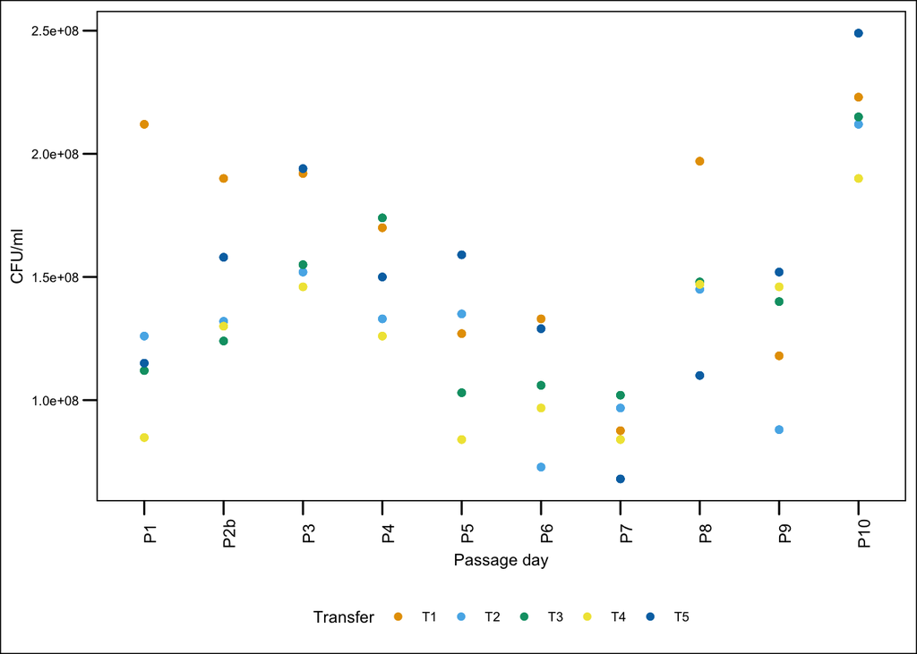

```r
# Plot bacteria concentration for each transfer
a<-ggplot(df,aes(Passage,CFU_ml, color=Transfer))+
  geom_point()+ # dot plot
    scale_color_manual(values=cbPalette)+ # color settings
  xlab("Passage day")+ # label x-axis
  ylab("CFU/ml")+ # label y-axis
  theme_base()+ # plot layout
  theme(text = element_text(size = 9),
         axis.title = element_text(size =9 ),
         axis.text.x = element_text(angle=90,size = 9),
         legend.position = "bottom") # font size and legend position
a
```

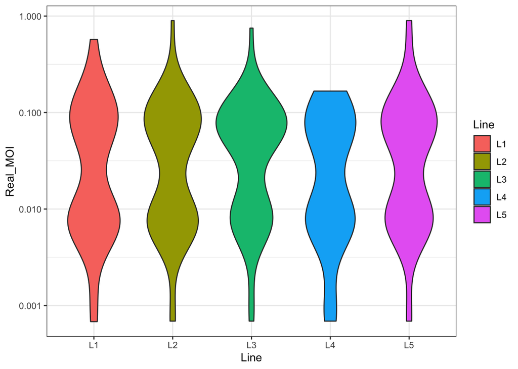

```r
# Visualize all MOI's in one plot (e.g. violin plot with different lines)
ggplot(df,aes(Line, Real_MOI, fill=Line))+
  geom_violin()+ # violin plot
  scale_y_continuous(trans="log10")+ # log transformation of y-axis
  theme_bw() # plot layout
```

### Visualize phage concentration

*Note* –> Phages after each 5th transfer T5 is accurate (after 3h incubation), was isolated using chloroform, the other 4x30 min titers were determined using a spot test, which was too inaccurate. To quantify correct free phage titer after 30-min transfers, see Experiment 6: Free phage titer quantification

### Plot phage concentrations after each 5th transfer (3-h amplification), quantified by plaque assay after chloroform extraction

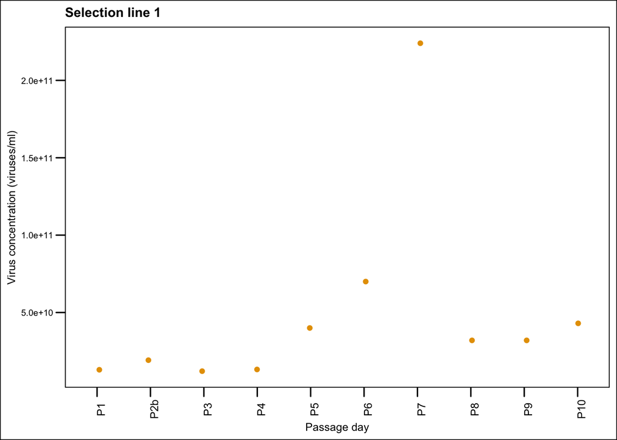

```r
# Phage concentration for individual selection lines
## Subset dataframe to only transfer 5 for each passage
df1<-df[df$Transfer=="T5",]

# Plot phage titers for each selection line in an individual plot (comments on plot h apply also to plots i-l)

## Line 1
h<-ggplot(df1[df1$Line=="L1",],aes(Passage,Output_phage_ml, group=Transfer, color=Transfer))+
  geom_point(position=position_jitterdodge())+ # dot plot with jitter to avoid point overlapping
   scale_color_manual(values = cbPalette)+ # color setting
      scale_x_discrete(limits = c("P1","P2b","P3","P4","P5","P6","P7","P8","P9","P10"))+ # order of passages
  xlab("Passage day")+ # label x-axis
  ylab("Virus concentration (viruses/ml)")+ # label y-axis
  ggtitle(("Selection line 1"))+ # plot title
  theme_base()+ # plot layout
  theme(text = element_text(size = 9),
         axis.title = element_text(size =9 ),
         axis.text.x = element_text(angle=90,size = 9),
         legend.position = "none") # font size and legend position
h
```

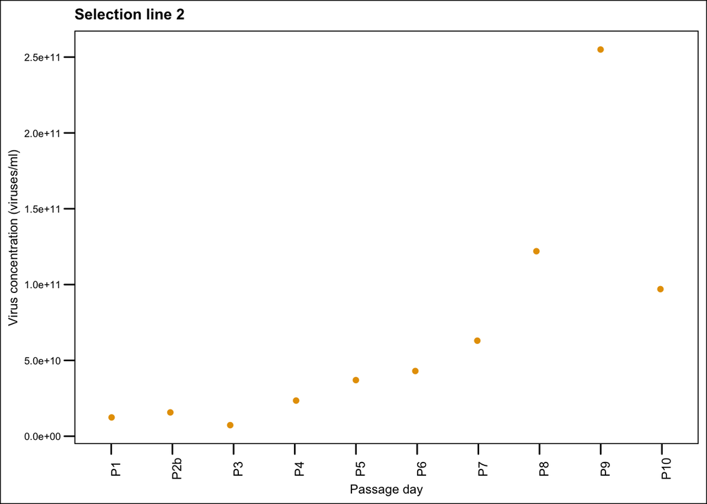

```r
## Line 2
i<-ggplot(df1[df1$Line=="L2",],aes(Passage,Output_phage_ml, group=Transfer, color=Transfer))+
  geom_point(position=position_jitterdodge())+
   scale_color_manual(values = cbPalette)+
      scale_x_discrete(limits = c("P1","P2b","P3","P4","P5","P6","P7","P8","P9","P10"))+
  xlab("Passage day")+
  ylab("Virus concentration (viruses/ml)")+
  ggtitle(("Selection line 2"))+
  theme_base()+
  theme(text = element_text(size = 9),
         axis.title = element_text(size =9 ),
         axis.text.x = element_text(angle=90,size = 9),
         legend.position = "none")
i
```

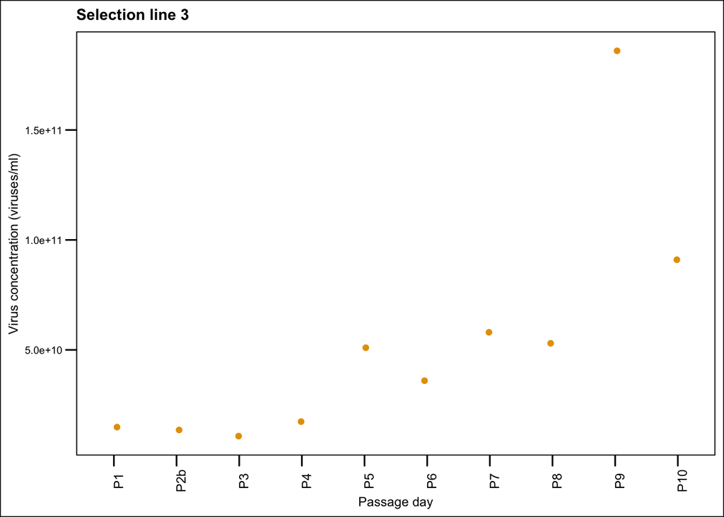

```r
# Line 3
j<-ggplot(df1[df1$Line=="L3",],aes(Passage,Output_phage_ml, group=Transfer, color=Transfer))+
  geom_point(position=position_jitterdodge())+
   scale_color_manual(values = cbPalette)+
      scale_x_discrete(limits = c("P1","P2b","P3","P4","P5","P6","P7","P8","P9","P10"))+
  xlab("Passage day")+
  ylab("Virus concentration (viruses/ml)")+
  ggtitle(("Selection line 3"))+
  theme_base()+
  theme(text = element_text(size = 9),
         axis.title = element_text(size =9 ),
         axis.text.x = element_text(angle=90,size = 9),
         legend.position = "none")
j
```

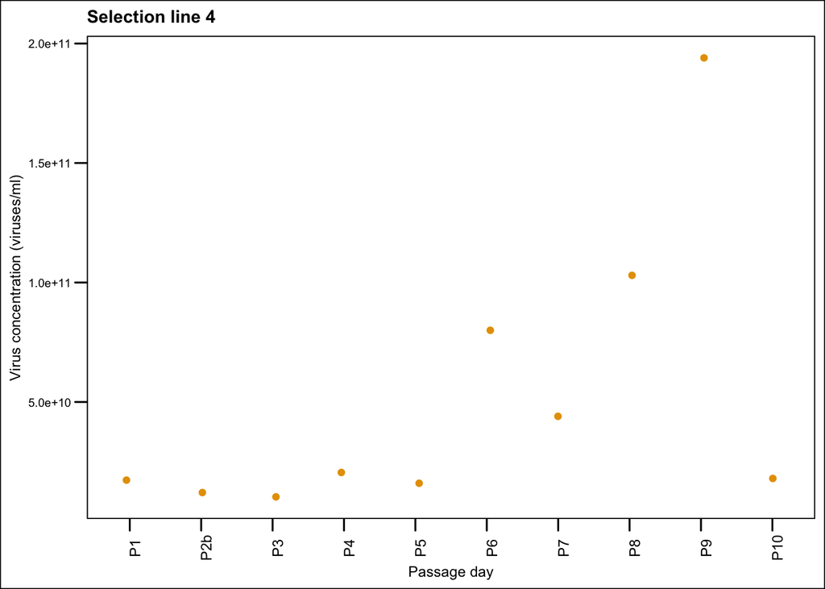

```r
# Line 4
k<-ggplot(df1[df1$Line=="L4",],aes(Passage,Output_phage_ml, group=Transfer, color=Transfer))+
  geom_point(position=position_jitterdodge())+
   scale_color_manual(values = cbPalette)+
      scale_x_discrete(limits = c("P1","P2b","P3","P4","P5","P6","P7","P8","P9","P10"))+
  xlab("Passage day")+
  ylab("Virus concentration (viruses/ml)")+
  ggtitle(("Selection line 4"))+
  theme_base()+
  theme(text = element_text(size = 9),
         axis.title = element_text(size =9 ),
         axis.text.x = element_text(angle=90,size = 9),
         legend.position = "none")
k
```

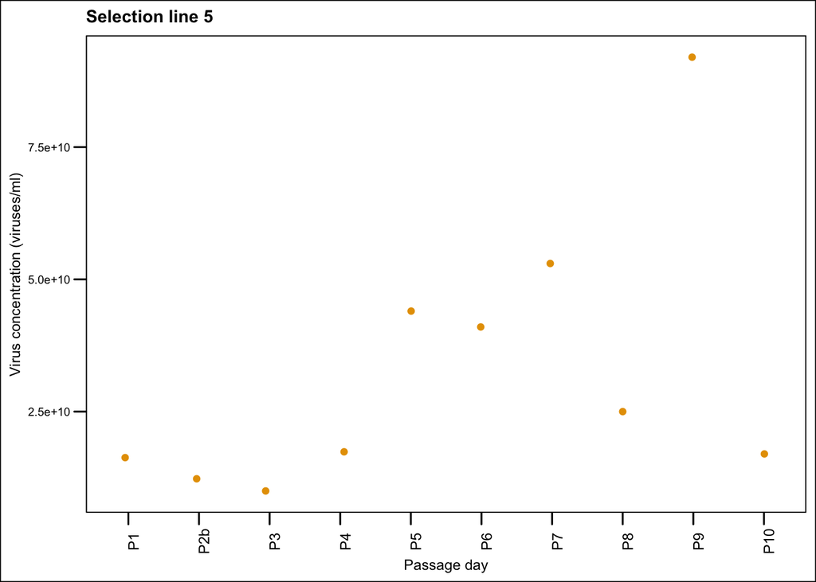

```r
# Line 5
l<-ggplot(df1[df1$Line=="L5",],aes(Passage,Output_phage_ml, group=Transfer, color=Transfer))+
  geom_point(position=position_jitterdodge())+
   scale_color_manual(values = cbPalette)+
      scale_x_discrete(limits = c("P1","P2b","P3","P4","P5","P6","P7","P8","P9","P10"))+
  xlab("Passage day")+
  ylab("Virus concentration (viruses/ml)")+
  ggtitle(("Selection line 5"))+
  theme_base()+
  theme(text = element_text(size = 9),
         axis.title = element_text(size =9 ),
         axis.text.x = element_text(angle=90,size = 9),
         legend.position = "none")
l
```

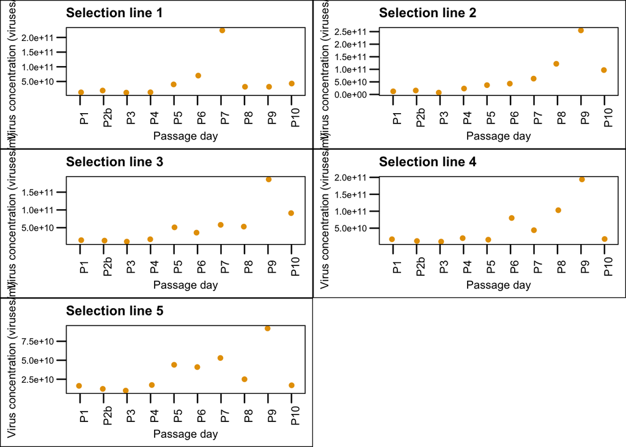

```r
# Combined plots of all lines
grid.arrange(h,i,j,k,l)
```

# Experiment 3: Adsorption constant analysis

Code used to generate Fig. S3A in the manuscript

**READ ME** *Specification of columns in data set*

- **Genotype**: Phage genotypes for which the adsorption assay was done: - wild type (WT) - small-plaque mutant G322D evolved in Experiment 1: 3-hour transfers - small-plaque mutant S427* evolved in Experiment 1: 3-hour transfers - large-plaque mutant T101A evolved in Experiment 2: 30-min transfers
- **Run**: Repeated experimental runs, different runs are biological replicates, ran on independent bacterial cultures started from independent colonies. Different number of runs for each phage genotype - Wild type: Runs 1,2,3,4,5,6,7 - T101A: Runs 5,6,7, - G322D: Runs 1,2,3,4,5,6,7 - S427*: Runs 1.,2,3,4,5,7
- **Sampling_time_min**: Sampling time point in minutes during the adsorption period from time point 2 minutes (initiation of adsorption) to 6 minutes in 2-minute time intervals.
- **PFU_1**: Plaque-forming unit counts (PFU) for the first plating of triplicate plating for phage lysate for each sampling time point
- **PFU_2**: Plaque-forming unit counts (PFU) for the second plating of triplicate plating for phage lysate for each sampling time point
- **PFU_3**: Plaque-forming unit counts (PFU) for third plating of triplicate plating for phage lysate for each sampling time point
- **Median_PFU**: Median PFU counts from triplicate plating PFU_1, PFU_2, PFU_3
- **Predilution**: After sampling at the adsorption time point 2 min to 6 min, 500 µl of sample was diluted in 4.5 ml of unsupplemented LB-medium cooled on ice to prevent infection cycle completion and secondary adsorptions, resulting in a 10-fold dilution of the sample.
- **Dilution_plating**: Plating dilution used to plate 100 µl of pre-diluted phage lysate from each sampling time point.
- **Dilution_in_ml**: Dilution step to calculate phage concentration in PFU/ml. Factor is 10x because 100 µl of phage lysate was used for plating.
- **PFU_ml**: Phage concentration in plaque-forming units per ml (PFU/ml), calculated as Median_PFU * Predilution * Dilution_plating * Dilution_in_ml
- **CFU**: Colony-forming units of wild-type E. coli C at the beginning of the adsorption period
- **Dilution_CFU**: Plating dilution used to plate CFUs; 100 µl of this dilution was plated for colony counts unless stated otherwise.
- **Bacteria_CFU_ml**: Bacteria concentration in colony-forming units per ml CFU/ml) at the start of the adsorption period. Calculated as counting colony-forming units (CFU) * Dilution_CFU * 10 (because 100 µl of Dilution_CFU were used for plating)

## Load data set

```r
df<-read.csv("experiment_3_adsorption_assay.csv")

# -> 69 observations of 14 variables
```

## Checking data set

```r
str(df)# structure of columns
```

```
## 'data.frame':    69 obs. of  14 variables:
##  $ Genotype         : chr  "G322D" "G322D" "G322D" "G322D" ...
##  $ Run              : int  1 1 1 2 2 2 3 3 3 4 ...
##  $ Sampling_time_min: int  2 4 6 2 4 6 2 4 6 2 ...
##  $ PFU_1            : int  51 18 22 68 152 36 36 33 42 191 ...
##  $ PFU_2            : int  38 18 20 81 146 29 32 68 52 151 ...
##  $ PFU_3            : int  49 24 18 72 96 37 15 40 71 129 ...
##  $ Median_PFU       : int  49 18 20 72 146 36 32 40 52 151 ...
##  $ Predilution      : int  10 10 10 10 10 10 10 10 10 10 ...
##  $ Dilution_plating : num  1000 100 10 1000 100 10 1000 100 10 1000 ...
##  $ Dilution_in_ml   : int  10 10 10 10 10 10 10 10 10 10 ...
##  $ PFU_ml           : num  4900000 180000 20000 7200000 1460000 36000 3200000 400000 52000 15100000 ...
##  $ CFU              : int  202 202 202 121 121 121 251 251 251 221 ...
##  $ Dilution_CFU     : num  1e+05 1e+05 1e+05 1e+05 1e+05 1e+05 1e+05 1e+05 1e+05 1e+05 ...
##  $ CFU_ml           : num  2.02e+08 2.02e+08 2.02e+08 1.21e+08 1.21e+08 1.21e+08 2.51e+08 2.51e+08 2.51e+08 2.21e+08 ...
```

```r
summary(df) # summary of columns
```

```
##    Genotype              Run        Sampling_time_min     PFU_1
##  Length:69          Min.   :1.000   Min.   :2         Min.   : 17.00
##  Class :character   1st Qu.:2.000   1st Qu.:2         1st Qu.: 33.00
##  Mode  :character   Median :4.000   Median :4         Median : 57.00
##                     Mean   :4.174   Mean   :4         Mean   : 71.97
##                     3rd Qu.:6.000   3rd Qu.:6         3rd Qu.: 94.00
##                     Max.   :7.000   Max.   :6         Max.   :261.00
##      PFU_2            PFU_3          Median_PFU      Predilution
##  Min.   : 13.00   Min.   : 14.00   Min.   : 14.00   Min.   :10
##  1st Qu.: 37.00   1st Qu.: 40.00   1st Qu.: 39.00   1st Qu.:10
##  Median : 61.00   Median : 61.00   Median : 58.00   Median :10
##  Mean   : 72.94   Mean   : 74.13   Mean   : 72.75   Mean   :10
##  3rd Qu.: 95.00   3rd Qu.: 96.00   3rd Qu.: 91.00   3rd Qu.:10
##  Max.   :312.00   Max.   :367.00   Max.   :261.00   Max.   :10
##  Dilution_plating Dilution_in_ml     PFU_ml              CFU
##  Min.   :   1.0   Min.   :10     Min.   :    2800   Min.   :121.0
##  1st Qu.:  10.0   1st Qu.:10     1st Qu.:   47000   1st Qu.:196.0
##  Median : 100.0   Median :10     Median :  390000   Median :221.0
##  Mean   : 190.4   Mean   :10     Mean   : 1229058   Mean   :235.2
##  3rd Qu.: 100.0   3rd Qu.:10     3rd Qu.: 1130000   3rd Qu.:267.0
##  Max.   :1000.0   Max.   :10     Max.   :15100000   Max.   :391.0
##   Dilution_CFU       CFU_ml
##  Min.   :1e+05   Min.   :121000000
##  1st Qu.:1e+05   1st Qu.:196000000
##  Median :1e+05   Median :221000000
##  Mean   :1e+05   Mean   :235217391
##  3rd Qu.:1e+05   3rd Qu.:267000000
##  Max.   :1e+05   Max.   :391000000
```

```r
# Convert Genotype and Run into factors
df$Genotype=as.factor(df$Genotype)
df$Run=as.factor(df$Run)
```

## Fitting linear model to log-transformed free phage titers to determine the adsorption curve slopes

```r
# Log transform free phage concentrations
df$log_PFU_ml=log(df$PFU_ml)
```

## Plot adsorption curves within run with all genotypes

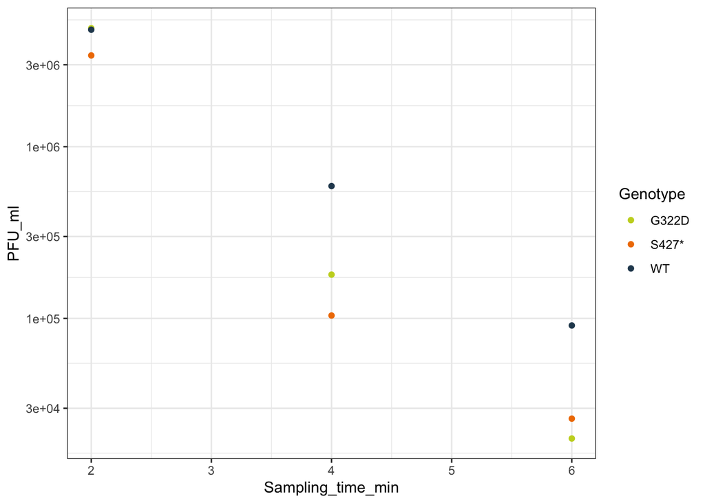

```r
# Comments of plot a also apply to plots b-g
# Run 1
a=ggplot(df[df$Run=="1",],aes(Sampling_time_min,PFU_ml, group=Genotype, color=Genotype))+
  geom_point()+ # dot plot
  scale_y_continuous(trans="log10")+ # log transformation of y-axis
  scale_color_manual(values=c("#c6d325","#ef7c00","#29485d"))+ # set color palette
  theme_bw() # plot layout
a
```

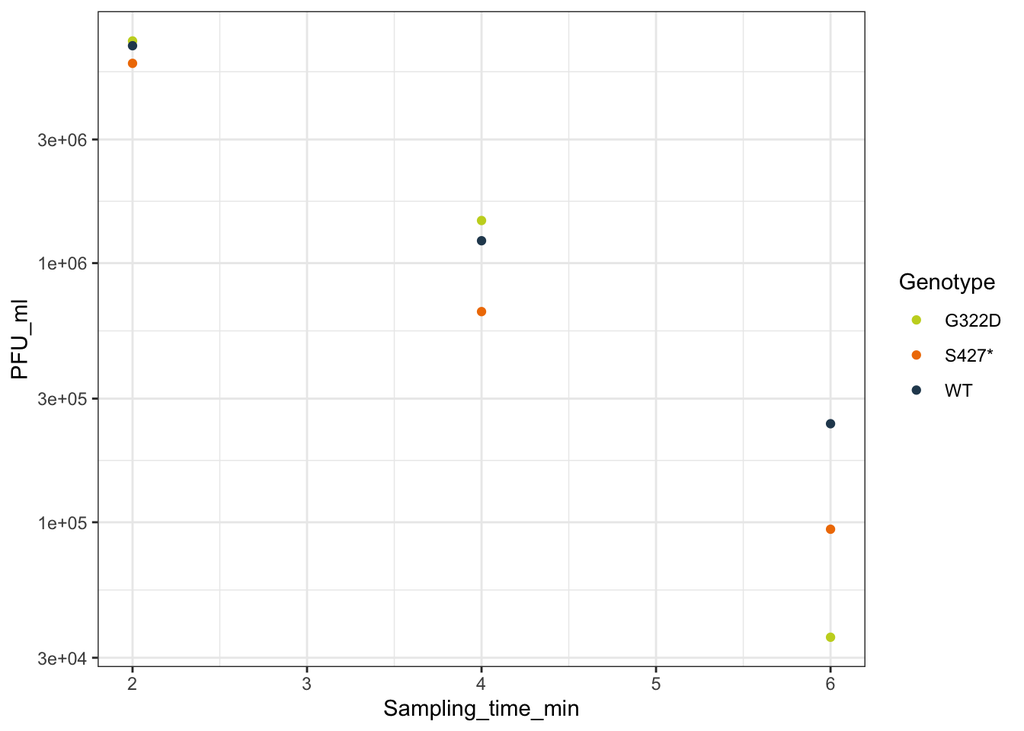

```r
# Run 2
b=ggplot(df[df$Run=="2",],aes(Sampling_time_min,PFU_ml, group=Genotype, color=Genotype))+
  geom_point()+
  scale_y_continuous(trans="log10")+
  scale_color_manual(values=c("#c6d325","#ef7c00","#29485d"))+
  theme_bw()
b
```

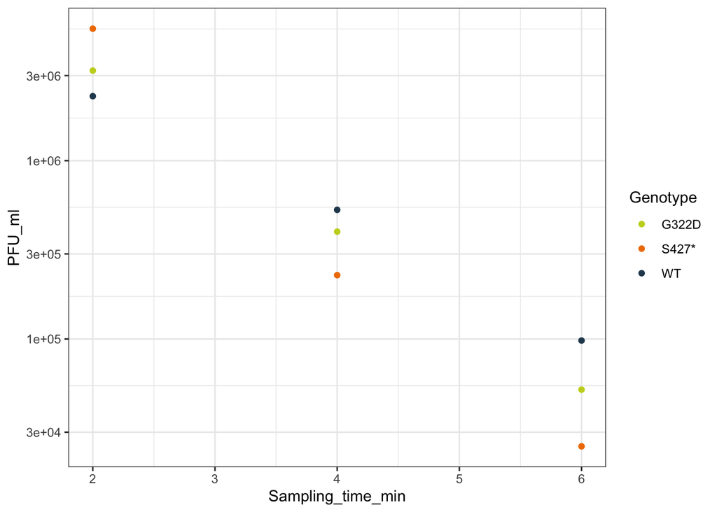

```r
# Run 3
c=ggplot(df[df$Run=="3",],aes(Sampling_time_min,PFU_ml, group=Genotype, color=Genotype))+
  geom_point()+
  scale_y_continuous(trans="log10")+
  scale_color_manual(values=c("#c6d325","#ef7c00","#29485d"))+
  theme_bw()
c
```

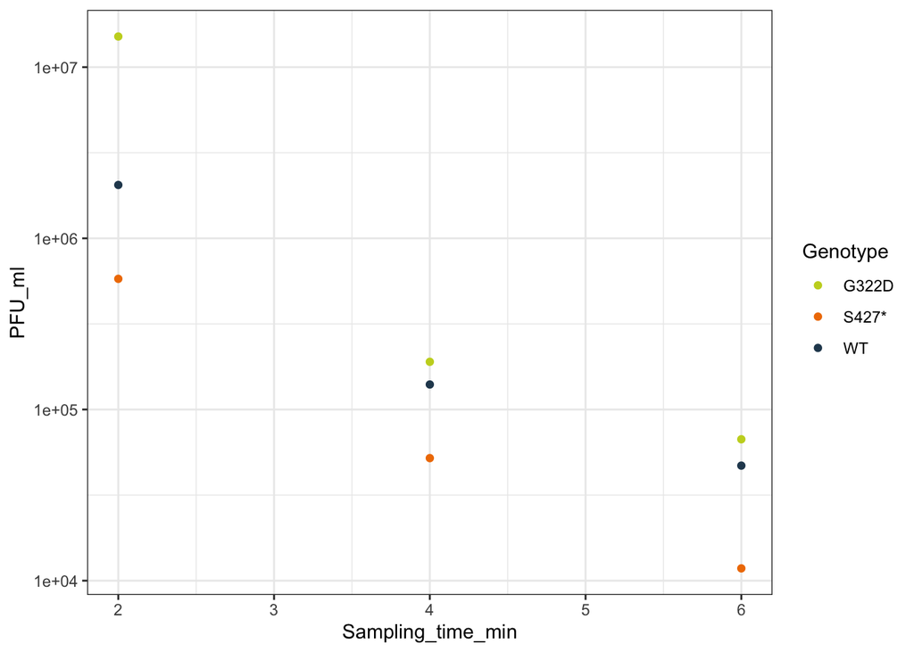

```r
# Run 4
d=ggplot(df[df$Run=="4",],aes(Sampling_time_min,PFU_ml, group=Genotype, color=Genotype))+
  geom_point()+
  scale_y_continuous(trans="log10")+
  scale_color_manual(values=c("#c6d325","#ef7c00","#29485d"))+
  theme_bw()
d
```

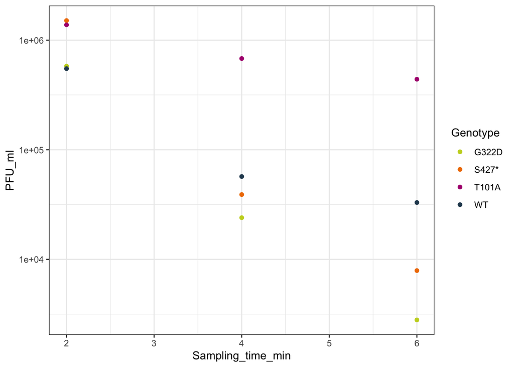

```r
# Run 5
e=ggplot(df[df$Run=="5",],aes(Sampling_time_min,PFU_ml, group=Genotype, color=Genotype))+
  geom_point()+
  scale_y_continuous(trans="log10")+
  scale_color_manual(values=c("#c6d325","#ef7c00","#ae017e","#29485d"))+
  theme_bw()
e
```

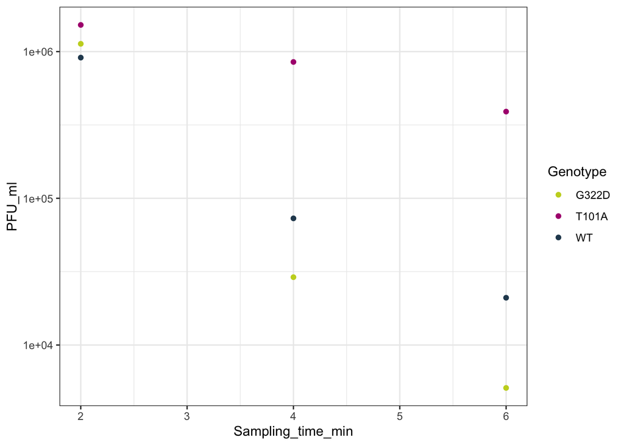

```r
# Run 6
f=ggplot(df[df$Run=="6",],aes(Sampling_time_min,PFU_ml, group=Genotype, color=Genotype))+
  geom_point()+
  scale_y_continuous(trans="log10")+
  scale_color_manual(values=c("#c6d325","#ae017e","#29485d"))+
  theme_bw()
f
```

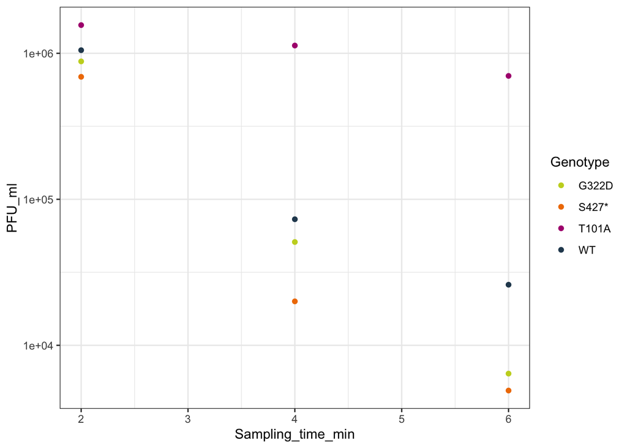

```r
# Run 7
g=ggplot(df[df$Run=="7",],aes(Sampling_time_min,PFU_ml, group=Genotype, color=Genotype))+
  geom_point()+
 # geom_smooth(method="lm", linetype="dashed", se=F)+
  scale_y_continuous(trans="log10")+
  scale_color_manual(values=c("#c6d325","#ef7c00","#ae017e","#29485d"))+
  theme_bw()
g
```

## Creat a dataframe to record slopes and R^2 values received as output from the model fit

```r
# Creat a data set to record slopes and R^2 values for each genotype and run, using subset df to time point 2 as a template
dfslope=df[df$Sampling_time_min==2,]

#-> dfslope should contain 23 observations of 6 variables

# Subset slope data set to only columns Run, Genotype and CFU_ml (Bacteria concentration needed for adsorption constant calculation)
dfslope=dfslope[,c(2,1,14)]

# Create unique identifier combining Genotype and Run
dfslope$ID=paste(dfslope$Run,dfslope$Genotype,sep="_")

# Create columns to record slope and R^2 values
dfslope$slope=NA
dfslope$R2=NA # multiple R^2
```

## Model fitting using a linear model for each genotype and run individually

### Ancestor

```r
# Each model represents an individual experimental run

a=lm(formula=log_PFU_ml~Sampling_time_min,data=df[df$Genotype=="WT" &df$Run==1,])
summary(a) #slope=-0.99138, R^2= 0.9989
```

```
##
## Call:
## lm(formula = log_PFU_ml ~ Sampling_time_min, data = df[df$Genotype ==
##     "WT" & df$Run == 1, ])
##
## Residuals:
##       49       50       51
##  0.03783 -0.07566  0.03783
##
## Coefficients:
##                   Estimate Std. Error t value Pr(>|t|)
## (Intercept)       17.32905    0.14155  122.42   0.0052 **
## Sampling_time_min -0.99138    0.03276  -30.26   0.0210 *
## ---
## Signif. codes:  0 '***' 0.001 '**' 0.01 '*' 0.05 '.' 0.1 ' ' 1
##
## Residual standard error: 0.09267 on 1 degrees of freedom
## Multiple R-squared:  0.9989, Adjusted R-squared:  0.9978
## F-statistic: 915.6 on 1 and 1 DF,  p-value: 0.02103
```

```r
dfslope[dfslope$ID=="1_WT",]$slope=- 0.99138
dfslope[dfslope$ID=="1_WT",]$R2= 0.9989

a=lm(formula=log_PFU_ml~Sampling_time_min,data=df[df$Genotype=="WT" &df$Run==2,])
summary(a) #slope=-0.83966 ,  R^2=0.9997
```

```
##
## Call:
## lm(formula = log_PFU_ml ~ Sampling_time_min, data = df[df$Genotype ==
##     "WT" & df$Run == 2, ])
##
## Residuals:
##       52       53       54
##  0.01778 -0.03557  0.01778
##
## Coefficients:
##                   Estimate Std. Error t value Pr(>|t|)
## (Intercept)       17.40857    0.06654  261.62  0.00243 **
## Sampling_time_min -0.83966    0.01540  -54.52  0.01168 *
## ---
## Signif. codes:  0 '***' 0.001 '**' 0.01 '*' 0.05 '.' 0.1 ' ' 1
##
## Residual standard error: 0.04356 on 1 degrees of freedom
## Multiple R-squared:  0.9997, Adjusted R-squared:  0.9993
## F-statistic:  2972 on 1 and 1 DF,  p-value: 0.01168
```

```r
dfslope[dfslope$ID=="2_WT",]$slope=- 0.83966
dfslope[dfslope$ID=="2_WT",]$R2= 0.9997

a=lm(formula=log_PFU_ml~Sampling_time_min,data=df[df$Genotype=="WT" &df$Run==3,])
summary(a) #slope=-0.78892, R^2=0.9984
```

```
##
## Call:
## lm(formula = log_PFU_ml ~ Sampling_time_min, data = df[df$Genotype ==
##     "WT" & df$Run == 3, ])
##
## Residuals:
##       55       56       57
## -0.03669  0.07337 -0.03669
##
## Coefficients:
##                   Estimate Std. Error t value Pr(>|t|)
## (Intercept)       16.26296    0.13727  118.47  0.00537 **
## Sampling_time_min -0.78892    0.03177  -24.83  0.02562 *
## ---
## Signif. codes:  0 '***' 0.001 '**' 0.01 '*' 0.05 '.' 0.1 ' ' 1
##
## Residual standard error: 0.08986 on 1 degrees of freedom
## Multiple R-squared:  0.9984, Adjusted R-squared:  0.9968
## F-statistic: 616.6 on 1 and 1 DF,  p-value: 0.02562
```

```r
dfslope[dfslope$ID=="3_WT",]$slope=- 0.78892
dfslope[dfslope$ID=="3_WT",]$R2= 0.9984

a=lm(formula=log_PFU_ml~Sampling_time_min,data=df[df$Genotype=="WT" &df$Run==4,])
summary(a) #slope=-0.9439,  R^2=0.944
```

```
##
## Call:
## lm(formula = log_PFU_ml ~ Sampling_time_min, data = df[df$Genotype ==
##     "WT" & df$Run == 4, ])
##
## Residuals:
##      58      59      60
##  0.2654 -0.5308  0.2654
##
## Coefficients:
##                   Estimate Std. Error t value Pr(>|t|)
## (Intercept)        16.1557     0.9931  16.268   0.0391 *
## Sampling_time_min  -0.9439     0.2299  -4.106   0.1521
## ---
## Signif. codes:  0 '***' 0.001 '**' 0.01 '*' 0.05 '.' 0.1 ' ' 1
##
## Residual standard error: 0.6501 on 1 degrees of freedom
## Multiple R-squared:  0.944,  Adjusted R-squared:  0.888
## F-statistic: 16.86 on 1 and 1 DF,  p-value: 0.1521
```

```r
dfslope[dfslope$ID=="4_WT",]$slope=- 0.9439
dfslope[dfslope$ID=="4_WT",]$R2= 0.944

a=lm(formula=log_PFU_ml~Sampling_time_min,data=df[df$Genotype=="WT" &df$Run==5,])
summary(a) #slope=-0.7034, R^2 0.8892
```

```
##
## Call:
## lm(formula = log_PFU_ml ~ Sampling_time_min, data = df[df$Genotype ==
##     "WT" & df$Run == 5, ])
##
## Residuals:
##      61      62      63
##  0.2867 -0.5734  0.2867
##
## Coefficients:
##                   Estimate Std. Error t value Pr(>|t|)
## (Intercept)        14.3377     1.0728  13.365   0.0475 *
## Sampling_time_min  -0.7034     0.2483  -2.833   0.2161
## ---
## Signif. codes:  0 '***' 0.001 '**' 0.01 '*' 0.05 '.' 0.1 ' ' 1
##
## Residual standard error: 0.7023 on 1 degrees of freedom
## Multiple R-squared:  0.8892, Adjusted R-squared:  0.7784
## F-statistic: 8.024 on 1 and 1 DF,  p-value: 0.2161
```

```r
dfslope[dfslope$ID=="5_WT",]$slope=- 0.7034
dfslope[dfslope$ID=="5_WT",]$R2= 0.8892

a=lm(formula=log_PFU_ml~Sampling_time_min,data=df[df$Genotype=="WT" &df$Run==6,])
summary(a) #slope=-0.9422,  R^2=0.9631
```

```
##
## Call:
## lm(formula = log_PFU_ml ~ Sampling_time_min, data = df[df$Genotype ==
##     "WT" & df$Run == 6, ])
##
## Residuals:
##      64      65      66
##  0.2128 -0.4257  0.2128
##
## Coefficients:
##                   Estimate Std. Error t value Pr(>|t|)
## (Intercept)        15.3928     0.7964  19.328   0.0329 *
## Sampling_time_min  -0.9422     0.1843  -5.112   0.1230
## ---
## Signif. codes:  0 '***' 0.001 '**' 0.01 '*' 0.05 '.' 0.1 ' ' 1
##
## Residual standard error: 0.5214 on 1 degrees of freedom
## Multiple R-squared:  0.9631, Adjusted R-squared:  0.9263
## F-statistic: 26.13 on 1 and 1 DF,  p-value: 0.123
```

```r
dfslope[dfslope$ID=="6_WT",]$slope=- 0.9422
dfslope[dfslope$ID=="6_WT",]$R2= 0.9631

a=lm(formula=log_PFU_ml~Sampling_time_min,data=df[df$Genotype=="WT" &df$Run==7,])
summary(a) #slope=-0.9246,  slope=0.9389
```

```
##
## Call:
## lm(formula = log_PFU_ml ~ Sampling_time_min, data = df[df$Genotype ==
##     "WT" & df$Run == 7, ])
##
## Residuals:
##      67      68      69
##  0.2723 -0.5446  0.2723
##
## Coefficients:
##                   Estimate Std. Error t value Pr(>|t|)
## (Intercept)        15.4412     1.0188  15.156   0.0419 *
## Sampling_time_min  -0.9246     0.2358  -3.921   0.1590
## ---
## Signif. codes:  0 '***' 0.001 '**' 0.01 '*' 0.05 '.' 0.1 ' ' 1
##
## Residual standard error: 0.667 on 1 degrees of freedom
## Multiple R-squared:  0.9389, Adjusted R-squared:  0.8779
## F-statistic: 15.37 on 1 and 1 DF,  p-value: 0.159
```

```r
dfslope[dfslope$ID=="7_WT",]$slope=- 0.9246
dfslope[dfslope$ID=="7_WT",]$R2= 0.9389
```

### Small plaque mutant F(G322D)

```r
# Each model represents an individual experimental run

a=lm(formula=log_PFU_ml~Sampling_time_min,data=df[df$Genotype=="G322D" &df$Run==1,])
summary(a) #slope=-1.3753, R^2=0.9867
```

```
##
## Call:
## lm(formula = log_PFU_ml ~ Sampling_time_min, data = df[df$Genotype ==
##     "G322D" & df$Run == 1, ])
##
## Residuals:
##       1       2       3
##  0.1845 -0.3689  0.1845
##
## Coefficients:
##                   Estimate Std. Error t value Pr(>|t|)
## (Intercept)        17.9709     0.6902  26.037   0.0244 *
## Sampling_time_min  -1.3753     0.1598  -8.609   0.0736 .
## ---
## Signif. codes:  0 '***' 0.001 '**' 0.01 '*' 0.05 '.' 0.1 ' ' 1
##
## Residual standard error: 0.4519 on 1 degrees of freedom
## Multiple R-squared:  0.9867, Adjusted R-squared:  0.9734
## F-statistic: 74.11 on 1 and 1 DF,  p-value: 0.07362
```

```r
dfslope[dfslope$ID=="1_G322D",]$slope=- 1.3753
dfslope[dfslope$ID=="1_G322D",]$R2= 0.9867

a=lm(formula=log_PFU_ml~Sampling_time_min,data=df[df$Genotype=="G322D" &df$Run==2,])
summary(a) #slope=-1.3246 , R^2= 0.9499
```

```
##
## Call:
## lm(formula = log_PFU_ml ~ Sampling_time_min, data = df[df$Genotype ==
##     "G322D" & df$Run == 2, ])
##
## Residuals:
##       4       5       6
## -0.3512  0.7023 -0.3512
##
## Coefficients:
##                   Estimate Std. Error t value Pr(>|t|)
## (Intercept)        18.7899     1.3140  14.300   0.0444 *
## Sampling_time_min  -1.3246     0.3041  -4.355   0.1437
## ---
## Signif. codes:  0 '***' 0.001 '**' 0.01 '*' 0.05 '.' 0.1 ' ' 1
##
## Residual standard error: 0.8602 on 1 degrees of freedom
## Multiple R-squared:  0.9499, Adjusted R-squared:  0.8998
## F-statistic: 18.97 on 1 and 1 DF,  p-value: 0.1437
```

```r
dfslope[dfslope$ID=="2_G322D",]$slope=- 1.3246
dfslope[dfslope$ID=="2_G322D",]$R2= 0.9499

a=lm(formula=log_PFU_ml~Sampling_time_min,data=df[df$Genotype=="G322D" &df$Run==3,])
summary(a) #slope-1.029916, R^21
```

```
##
## Call:
## lm(formula = log_PFU_ml ~ Sampling_time_min, data = df[df$Genotype ==
##     "G322D" & df$Run == 3, ])
##
## Residuals:
##         7         8         9
##  0.006537 -0.013074  0.006537
##
## Coefficients:
##                    Estimate Std. Error t value Pr(>|t|)
## (Intercept)       17.031956   0.024458   696.4 0.000914 ***
## Sampling_time_min -1.029916   0.005661  -181.9 0.003499 **
## ---
## Signif. codes:  0 '***' 0.001 '**' 0.01 '*' 0.05 '.' 0.1 ' ' 1
##
## Residual standard error: 0.01601 on 1 degrees of freedom
## Multiple R-squared:      1,  Adjusted R-squared:  0.9999
## F-statistic: 3.31e+04 on 1 and 1 DF,  p-value: 0.003499
```

```r
dfslope[dfslope$ID=="3_G322D",]$slope=- 1.029916
dfslope[dfslope$ID=="3_G322D",]$R2= 1

a=lm(formula=log_PFU_ml~Sampling_time_min,data=df[df$Genotype=="G322D" &df$Run==4,])
summary(a) #slope=-1.3544,  R^2=0.888
```

```
##
## Call:
## lm(formula = log_PFU_ml ~ Sampling_time_min, data = df[df$Genotype ==
##     "G322D" & df$Run == 4, ])
##
## Residuals:
##      10      11      12
##  0.5555 -1.1110  0.5555
##
## Coefficients:
##                   Estimate Std. Error t value Pr(>|t|)
## (Intercept)        18.6836     2.0785   8.989   0.0705 .
## Sampling_time_min  -1.3544     0.4811  -2.815   0.2173
## ---
## Signif. codes:  0 '***' 0.001 '**' 0.01 '*' 0.05 '.' 0.1 ' ' 1
##
## Residual standard error: 1.361 on 1 degrees of freedom
## Multiple R-squared:  0.888,  Adjusted R-squared:  0.7759
## F-statistic: 7.926 on 1 and 1 DF,  p-value: 0.2173
```

```r
dfslope[dfslope$ID=="4_G322D",]$slope=- 1.3544
dfslope[dfslope$ID=="4_G322D",]$R2= 0.888

a=lm(formula=log_PFU_ml~Sampling_time_min,data=df[df$Genotype=="G322D" &df$Run==5,])
summary(a) #slope=-1.3334, R^2= 0.9876
```

```
##
## Call:
## lm(formula = log_PFU_ml ~ Sampling_time_min, data = df[df$Genotype ==
##     "G322D" & df$Run == 5, ])
##
## Residuals:
##      13      14      15
##  0.1728 -0.3455  0.1728
##
## Coefficients:
##                   Estimate Std. Error t value Pr(>|t|)
## (Intercept)        15.7647     0.6464  24.389   0.0261 *
## Sampling_time_min  -1.3334     0.1496  -8.912   0.0711 .
## ---
## Signif. codes:  0 '***' 0.001 '**' 0.01 '*' 0.05 '.' 0.1 ' ' 1
##
## Residual standard error: 0.4232 on 1 degrees of freedom
## Multiple R-squared:  0.9876, Adjusted R-squared:  0.9751
## F-statistic: 79.43 on 1 and 1 DF,  p-value: 0.07114
```

```r
dfslope[dfslope$ID=="5_G322D",]$slope=- 1.3334
dfslope[dfslope$ID=="5_G322D",]$R2= 0.9876

a=lm(formula=log_PFU_ml~Sampling_time_min,data=df[df$Genotype=="G322D" &df$Run==6,])
summary(a) #slope=-1.3502, R^2=0.9594
```

```
##
## Call:
## lm(formula = log_PFU_ml ~ Sampling_time_min, data = df[df$Genotype ==
##     "G322D" & df$Run == 6, ])
##
## Residuals:
##      16      17      18
##  0.3208 -0.6415  0.3208
##
## Coefficients:
##                   Estimate Std. Error t value Pr(>|t|)
## (Intercept)        16.3173     1.2002   13.60   0.0467 *
## Sampling_time_min  -1.3502     0.2778   -4.86   0.1292
## ---
## Signif. codes:  0 '***' 0.001 '**' 0.01 '*' 0.05 '.' 0.1 ' ' 1
##
## Residual standard error: 0.7857 on 1 degrees of freedom
## Multiple R-squared:  0.9594, Adjusted R-squared:  0.9188
## F-statistic: 23.62 on 1 and 1 DF,  p-value: 0.1292
```

```r
dfslope[dfslope$ID=="6_G322D",]$slope=- 1.3502
dfslope[dfslope$ID=="6_G322D",]$R2= 0.9594

a=lm(formula=log_PFU_ml~Sampling_time_min,data=df[df$Genotype=="G322D" &df$Run==7,])
summary(a) #slope=-1.2309,  R^2=0.9919
```

```
##
## Call:
## lm(formula = log_PFU_ml ~ Sampling_time_min, data = df[df$Genotype ==
##     "G322D" & df$Run == 7, ])
##
## Residuals:
##      19      20      21
##  0.1288 -0.2575  0.1288
##
## Coefficients:
##                   Estimate Std. Error t value Pr(>|t|)
## (Intercept)        16.0207     0.4818   33.25   0.0191 *
## Sampling_time_min  -1.2309     0.1115  -11.04   0.0575 .
## ---
## Signif. codes:  0 '***' 0.001 '**' 0.01 '*' 0.05 '.' 0.1 ' ' 1
##
## Residual standard error: 0.3154 on 1 degrees of freedom
## Multiple R-squared:  0.9919, Adjusted R-squared:  0.9837
## F-statistic: 121.8 on 1 and 1 DF,  p-value: 0.05752
```

```r
dfslope[dfslope$ID=="7_G322D",]$slope=- 1.2309
dfslope[dfslope$ID=="7_G322D",]$R2= 0.9919
```

### Small plaque mutant F(S427*)

```r
# Each model represents an individual experimental run

a=lm(formula=log_PFU_ml~Sampling_time_min,data=df[df$Genotype=="S427*" &df$Run==1,])
summary(a) #slope-1.2174, R^2= 0.9414
```

```
##
## Call:
## lm(formula = log_PFU_ml ~ Sampling_time_min, data = df[df$Genotype ==
##     "S427*" & df$Run == 1, ])
##
## Residuals:
##      22      23      24
##  0.3508 -0.7016  0.3508
##
## Coefficients:
##                   Estimate Std. Error t value Pr(>|t|)
## (Intercept)        17.1233     1.3125  13.046   0.0487 *
## Sampling_time_min  -1.2174     0.3038  -4.007   0.1557
## ---
## Signif. codes:  0 '***' 0.001 '**' 0.01 '*' 0.05 '.' 0.1 ' ' 1
##
## Residual standard error: 0.8592 on 1 degrees of freedom
## Multiple R-squared:  0.9414, Adjusted R-squared:  0.8828
## F-statistic: 16.06 on 1 and 1 DF,  p-value: 0.1557
```

```r
dfslope[dfslope$ID=="1_S427*",]$slope=- 1.2174
dfslope[dfslope$ID=="1_S427*",]$R2= 0.9414

a=lm(formula=log_PFU_ml~Sampling_time_min,data=df[df$Genotype=="S427*" &df$Run==2,])
summary(a) #slope=-1.03485 ,  R^2=0.9986
```

```
##
## Call:
## lm(formula = log_PFU_ml ~ Sampling_time_min, data = df[df$Genotype ==
##     "S427*" & df$Run == 2, ])
##
## Residuals:
##       25       26       27
##  0.04534 -0.09069  0.04534
##
## Coefficients:
##                   Estimate Std. Error t value Pr(>|t|)
## (Intercept)       17.61483    0.16966  103.83  0.00613 **
## Sampling_time_min -1.03485    0.03927  -26.35  0.02415 *
## ---
## Signif. codes:  0 '***' 0.001 '**' 0.01 '*' 0.05 '.' 0.1 ' ' 1
##
## Residual standard error: 0.1111 on 1 degrees of freedom
## Multiple R-squared:  0.9986, Adjusted R-squared:  0.9971
## F-statistic: 694.5 on 1 and 1 DF,  p-value: 0.02415
```

```r
dfslope[dfslope$ID=="2_S427*",]$slope=- 1.03485
dfslope[dfslope$ID=="2_S427*",]$R2= 0.9986

a=lm(formula=log_PFU_ml~Sampling_time_min,data=df[df$Genotype=="S427*" &df$Run==3,])
summary(a) #slope=-1.3484, R^2=0.9893
```

```
##
## Call:
## lm(formula = log_PFU_ml ~ Sampling_time_min, data = df[df$Genotype ==
##     "S427*" & df$Run == 3, ])
##
## Residuals:
##      28      29      30
##  0.1621 -0.3242  0.1621
##
## Coefficients:
##                   Estimate Std. Error t value Pr(>|t|)
## (Intercept)        18.0550     0.6066  29.765   0.0214 *
## Sampling_time_min  -1.3484     0.1404  -9.604   0.0660 .
## ---
## Signif. codes:  0 '***' 0.001 '**' 0.01 '*' 0.05 '.' 0.1 ' ' 1
##
## Residual standard error: 0.3971 on 1 degrees of freedom
## Multiple R-squared:  0.9893, Adjusted R-squared:  0.9786
## F-statistic: 92.24 on 1 and 1 DF,  p-value: 0.06605
```

```r
dfslope[dfslope$ID=="3_S427*",]$slope=- 1.3484
dfslope[dfslope$ID=="3_S427*",]$R2= 0.9893

a=lm(formula=log_PFU_ml~Sampling_time_min,data=df[df$Genotype=="S427*" &df$Run==4,])
summary(a) #slope=-0.9737, R^2= 0.9814
```

```
##
## Call:
## lm(formula = log_PFU_ml ~ Sampling_time_min, data = df[df$Genotype ==
##     "S427*" & df$Run == 4, ])
##
## Residuals:
##      31      32      33
##  0.1548 -0.3095  0.1548
##
## Coefficients:
##                   Estimate Std. Error t value Pr(>|t|)
## (Intercept)        15.0635     0.5791  26.011   0.0245 *
## Sampling_time_min  -0.9737     0.1340  -7.265   0.0871 .
## ---
## Signif. codes:  0 '***' 0.001 '**' 0.01 '*' 0.05 '.' 0.1 ' ' 1
##
## Residual standard error: 0.3791 on 1 degrees of freedom
## Multiple R-squared:  0.9814, Adjusted R-squared:  0.9628
## F-statistic: 52.77 on 1 and 1 DF,  p-value: 0.08709
```

```r
dfslope[dfslope$ID=="4_S427*",]$slope=- 0.9737
dfslope[dfslope$ID=="4_S427*",]$R2= 0.9814

a=lm(formula=log_PFU_ml~Sampling_time_min,data=df[df$Genotype=="S427*" &df$Run==5,])
summary(a) #slope=-1.3133, R^2= 0.9513
```

```
##
## Call:
## lm(formula = log_PFU_ml ~ Sampling_time_min, data = df[df$Genotype ==
##     "S427*" & df$Run == 5, ])
##
## Residuals:
##      34      35      36
##  0.3433 -0.6865  0.3433
##
## Coefficients:
##                   Estimate Std. Error t value Pr(>|t|)
## (Intercept)        16.5109     1.2844  12.855   0.0494 *
## Sampling_time_min  -1.3133     0.2973  -4.418   0.1417
## ---
## Signif. codes:  0 '***' 0.001 '**' 0.01 '*' 0.05 '.' 0.1 ' ' 1
##
## Residual standard error: 0.8408 on 1 degrees of freedom
## Multiple R-squared:  0.9513, Adjusted R-squared:  0.9025
## F-statistic: 19.52 on 1 and 1 DF,  p-value: 0.1417
```

```r
dfslope[dfslope$ID=="5_S427*",]$slope=- 1.3133
dfslope[dfslope$ID=="5_S427*",]$R2= 0.9513

a=lm(formula=log_PFU_ml~Sampling_time_min,data=df[df$Genotype=="S427*" &df$Run==7,])
summary(a) #slope=-1.2369,  R^2=0.9416
```

```
##
## Call:
## lm(formula = log_PFU_ml ~ Sampling_time_min, data = df[df$Genotype ==
##     "S427*" & df$Run == 7, ])
##
## Residuals:
##      37      38      39
##  0.3557 -0.7115  0.3557
##
## Coefficients:
##                   Estimate Std. Error t value Pr(>|t|)
## (Intercept)        15.5624     1.3311  11.692   0.0543 .
## Sampling_time_min  -1.2369     0.3081  -4.015   0.1554
## ---
## Signif. codes:  0 '***' 0.001 '**' 0.01 '*' 0.05 '.' 0.1 ' ' 1
##
## Residual standard error: 0.8714 on 1 degrees of freedom
## Multiple R-squared:  0.9416, Adjusted R-squared:  0.8832
## F-statistic: 16.12 on 1 and 1 DF,  p-value: 0.1554
```

```r
dfslope[dfslope$ID=="7_S427*",]$slope=- 1.2369
dfslope[dfslope$ID=="7_S427*",]$R2= 0.9416
```

### Large plaque mutant F(T101A)

```r
# Each model represents an individual experimental run

a=lm(formula=log_PFU_ml~Sampling_time_min,data=df[df$Genotype=="T101A" &df$Run==5,])
summary(a) #slope=-0.28577, R^2= 0.9814
```

```
##
## Call:
## lm(formula = log_PFU_ml ~ Sampling_time_min, data = df[df$Genotype ==
##     "T101A" & df$Run == 5, ])
##
## Residuals:
##       40       41       42
##  0.04540 -0.09081  0.04540
##
## Coefficients:
##                   Estimate Std. Error t value Pr(>|t|)
## (Intercept)       14.66372    0.16989  86.314  0.00738 **
## Sampling_time_min -0.28577    0.03932  -7.267  0.08705 .
## ---
## Signif. codes:  0 '***' 0.001 '**' 0.01 '*' 0.05 '.' 0.1 ' ' 1
##
## Residual standard error: 0.1112 on 1 degrees of freedom
## Multiple R-squared:  0.9814, Adjusted R-squared:  0.9628
## F-statistic: 52.82 on 1 and 1 DF,  p-value: 0.08705
```

```r
dfslope[dfslope$ID=="5_T101A",]$slope=- 0.28577
dfslope[dfslope$ID=="5_T101A",]$R2= 0.9814

a=lm(formula=log_PFU_ml~Sampling_time_min,data=df[df$Genotype=="T101A" &df$Run==6,])
summary(a) #slope=-0.34008, R^2= 0.993
```

```
##
## Call:
## lm(formula = log_PFU_ml ~ Sampling_time_min, data = df[df$Genotype ==
##     "T101A" & df$Run == 6, ])
##
## Residuals:
##       43       44       45
## -0.03298  0.06595 -0.03298
##
## Coefficients:
##                   Estimate Std. Error t value Pr(>|t|)
## (Intercept)       14.94736    0.12339  121.14  0.00526 **
## Sampling_time_min -0.34008    0.02856  -11.91  0.05334 .
## ---
## Signif. codes:  0 '***' 0.001 '**' 0.01 '*' 0.05 '.' 0.1 ' ' 1
##
## Residual standard error: 0.08078 on 1 degrees of freedom
## Multiple R-squared:  0.993,  Adjusted R-squared:  0.986
## F-statistic: 141.8 on 1 and 1 DF,  p-value: 0.05334
```

```r
dfslope[dfslope$ID=="6_T101A",]$slope=- 0.34008
dfslope[dfslope$ID=="6_T101A",]$R2= 0.993

a=lm(formula=log_PFU_ml~Sampling_time_min,data=df[df$Genotype=="T101A" &df$Run==7,])
summary(a) #slope=-0.20034, R^2= 0.9875
```

```
##
## Call:
## lm(formula = log_PFU_ml ~ Sampling_time_min, data = df[df$Genotype ==
##     "T101A" & df$Run == 7, ])
##
## Residuals:
##       46       47       48
## -0.02607  0.05214 -0.02607
##
## Coefficients:
##                   Estimate Std. Error t value Pr(>|t|)
## (Intercept)       14.68695    0.09755 150.562  0.00423 **
## Sampling_time_min -0.20034    0.02258  -8.873  0.07144 .
## ---
## Signif. codes:  0 '***' 0.001 '**' 0.01 '*' 0.05 '.' 0.1 ' ' 1
##
## Residual standard error: 0.06386 on 1 degrees of freedom
## Multiple R-squared:  0.9875, Adjusted R-squared:  0.9749
## F-statistic: 78.74 on 1 and 1 DF,  p-value: 0.07144
```

```r
dfslope[dfslope$ID=="7_T101A",]$slope=- 0.20034
dfslope[dfslope$ID=="7_T101A",]$R2= 0.9875
```

## Determine minimum and maximum R^2 value

```r
summary(dfslope)
```

```
##  Run    Genotype     CFU_ml               ID                slope
##  1:3   G322D:7   Min.   :121000000   Length:23          Min.   :-1.3753
##  2:3   S427*:6   1st Qu.:196000000   Class :character   1st Qu.:-1.3190
##  3:3   T101A:3   Median :221000000   Mode  :character   Median :-1.0299
##  4:3   WT   :7   Mean   :235217391                      Mean   :-1.0036
##  5:4             3rd Qu.:267000000                      3rd Qu.:-0.8821
##  6:3             Max.   :391000000                      Max.   :-0.2003
##  7:4
##        R2
##  Min.   :0.8880
##  1st Qu.:0.9469
##  Median :0.9814
##  Mean   :0.9679
##  3rd Qu.:0.9925
##  Max.   :1.0000
##
```

```r
# min: 0.89
# max: 1.00
```

## Calculate adsorption constants for each genotype and experimental run

Formula for calculating k: k (ml^-1 min^-1)= -slope/Bacteria concentration (CFU_ml)

```r
# Calculate adsorption rate constant k
dfslope$k=-(dfslope$slope)/(dfslope$CFU_ml)
```

## Export dfslopes dataframe with the analysed slopes and R^2 values

```r
#write.csv(dfslope,"experiment_3_slope_analysis.csv")
```

## Calculate mean and se of adsorption rate constant

```r
## WT
mean(dfslope[dfslope$Genotype=="WT",]$k) #4.146119e-09
```

```
## [1] 4.146119e-09
```

```r
std.error(dfslope[dfslope$Genotype=="WT",]$k) #5.982199e-10
```

```
## [1] 5.982199e-10
```

```r
## T101A
mean(dfslope[dfslope$Genotype=="T101A",]$k) # 9.874041e-10
```

```
## [1] 9.874041e-10
```

```r
std.error(dfslope[dfslope$Genotype=="T101A",]$k) #6.043767e-11
```

```
## [1] 6.043767e-11
```

```r
## G322D
mean(dfslope[dfslope$Genotype=="G322D",]$k) # 6.102084e-09
```

```
## [1] 6.102084e-09
```

```r
std.error(dfslope[dfslope$Genotype=="G322D",]$k) #9.289692e-10
```

```
## [1] 9.289692e-10
```

```r
## S427*
mean(dfslope[dfslope$Genotype=="S427*",]$k) #5.931108e-09
```

```
## [1] 5.931108e-09
```

```r
std.error(dfslope[dfslope$Genotype=="S427*",]$k) #5.968958e-10
```

```
## [1] 5.968958e-10
```

## Test for statistical significant differences in adsorption constants between genotypes

### Test for normality and heterogeneity of variances

```r
# Test for normal distribution
shapiro.test(dfslope$k) # passed: W = 0.9632, p-value = 0.5309
```

```
##
##  Shapiro-Wilk normality test
##
## data:  dfslope$k
## W = 0.9632, p-value = 0.5309
```

```r
# Homogeneity of variances
leveneTest(k ~ Genotype, data = dfslope) # passed:  group DF= 3, group sample= 19, F-value= 1.2369  p=0.324
```

```
## Levene's Test for Homogeneity of Variance (center = median)
##       Df F value Pr(>F)
## group  3  1.2369  0.324
##       19
```

### Linear mixed model used to test for differences between genotypes

```r
# Linear mixed effects model with Genotype as fixed effect and run as random effect

## Full model
m1<- lmer(k~Genotype +(1|Run) ,data= dfslope )
## Null model
m2<- lmer(k~1 +(1|Run),data=dfslope)

# Model comparison using anova to test if including genotype into the model significantly contributes to explaining adsorption constant variation
anova(m1,m2)
```

```
## refitting model(s) with ML (instead of REML)
```

```
## Data: dfslope
## Models:
## m2: k ~ 1 + (1 | Run)
## m1: k ~ Genotype + (1 | Run)
##    npar     AIC     BIC logLik deviance  Chisq Df Pr(>Chisq)
## m2    3 -847.21 -843.80 426.60  -853.21
## m1    6 -870.97 -864.16 441.49  -882.97 29.764  3  1.548e-06 ***
## ---
## Signif. codes:  0 '***' 0.001 '**' 0.01 '*' 0.05 '.' 0.1 ' ' 1
```

*Results of Anova* Analysis of Variance Table Models: m2: k ~ 1 + (1 | Run) m1: k ~ Genotype + (1 | Run) npar AIC BIC logLik deviance Chisq Df Pr(>Chisq)  
m2 3 -847.21 -843.80 426.60 -853.21  
m1 6 -870.97 -864.16 441.49 -882.97 29.764 3 1.548e-06 ***

### Summary of model

```r
summary(m1)
```

```
## Linear mixed model fit by REML ['lmerMod']
## Formula: k ~ Genotype + (1 | Run)
##    Data: dfslope
##
## REML criterion at convergence: -718.6
##
## Scaled residuals:
##      Min       1Q   Median       3Q      Max
## -1.23170 -0.50637  0.04028  0.48679  1.95181
##
## Random effects:
##  Groups   Name        Variance  Std.Dev.
##  Run      (Intercept) 2.822e-18 1.680e-09
##  Residual             6.623e-19 8.138e-10
## Number of obs: 23, groups:  Run, 7
##
## Fixed effects:
##                 Estimate Std. Error t value
## (Intercept)    6.102e-09  7.055e-10   8.649
## GenotypeS427* -4.454e-10  4.586e-10  -0.971
## GenotypeT101A -4.292e-09  5.983e-10  -7.173
## GenotypeWT    -1.956e-09  4.350e-10  -4.496
##
## Correlation of Fixed Effects:
##             (Intr) GS427* GT101A
## GentypS427* -0.292
## GentypT101A -0.224  0.313
## GenotypeWT  -0.308  0.474  0.364
```

*Results of Model m1 summary* Linear mixed model fit by REML [‘lmerMod’] Formula: k ~ Genotype + (1 | Run) Data: dfslope

REML criterion at convergence: -718.6

Scaled residuals: Min 1Q Median 3Q Max -1.23170 -0.50637 0.04028 0.48679 1.95181

Random effects: Groups Name Variance Std.Dev. Run (Intercept) 2.822e-18 1.680e-09 Residual 6.623e-19 8.138e-10 Number of obs: 23, groups: Run, 7

Fixed effects: Estimate Std. Error t value (Intercept) 6.102e-09 7.055e-10 8.649 GenotypeS427* -4.454e-10 4.586e-10 -0.971 GenotypeT101A -4.292e-09 5.983e-10 -7.173 GenotypeWT -1.956e-09 4.350e-10 -4.496

Correlation of Fixed Effects: (Intr) GS427* GT101A GentypS427* -0.292  
GentypT101A -0.224 0.313  
GenotypeWT -0.308 0.474 0.364

### Multiple comparison to compare between genotypes

```r
# Using Tukey-HSD as Post-Hoc test for mutliple comparison
summary(glht(m1,linfct=mcp(Genotype="Tukey")),test=adjusted("holm"))
```

```
##
##   Simultaneous Tests for General Linear Hypotheses
##
## Multiple Comparisons of Means: Tukey Contrasts
##
##
## Fit: lmer(formula = k ~ Genotype + (1 | Run), data = dfslope)
##
## Linear Hypotheses:
##                      Estimate Std. Error z value Pr(>|z|)
## S427* - G322D == 0 -4.454e-10  4.586e-10  -0.971 0.331457
## T101A - G322D == 0 -4.292e-09  5.983e-10  -7.173 4.40e-12 ***
## WT - G322D == 0    -1.956e-09  4.350e-10  -4.496 2.76e-05 ***
## T101A - S427* == 0 -3.846e-09  6.296e-10  -6.109 5.02e-09 ***
## WT - S427* == 0    -1.511e-09  4.586e-10  -3.294 0.001977 **
## WT - T101A == 0     2.336e-09  5.983e-10   3.904 0.000284 ***
## ---
## Signif. codes:  0 '***' 0.001 '**' 0.01 '*' 0.05 '.' 0.1 ' ' 1
## (Adjusted p values reported -- holm method)
```

*Results of Post-Hoc Multiple comparison testing* Simultaneous Tests for General Linear Hypotheses

Multiple Comparisons of Means: Tukey Contrasts

Fit: lmer(formula = k ~ Genotype + (1 | Run), data = dfslope)

Linear Hypotheses: Estimate Std. Error z value Pr(>|z|)  
S427* - G322D == 0 -4.454e-10 4.586e-10 -0.971 0.331457  
T101A - G322D == 0 -4.292e-09 5.983e-10 -7.173 4.40e-12 *WT - G322D == 0 -1.956e-09 4.350e-10 -4.496 2.76e-05* T101A - S427* == 0 -3.846e-09 6.296e-10 -6.109 5.02e-09 *WT - S427* == 0 -1.511e-09 4.586e-10 -3.294 0.001977 WT - T101A == 0 2.336e-09 5.983e-10 3.904 0.000284 ***

Signif. codes: 0 ‘**’ 0.001 ‘**’ 0.01 ‘’ 0.05 ‘.’ 0.1 ‘ ’ 1 (Adjusted p values reported – holm method)

### Model validation (Fig. S13)

```r
#output_file <- "adsorption_statistics_model_checking.jpeg"
#jpeg(filename = output_file, width = 8, height = 4, units = "in", res = 600)

## Plot layout
par(mfrow=c(1,2))

## qqplot
qqPlot(residuals(m1))
```

```
##  4 16
##  2  6
```

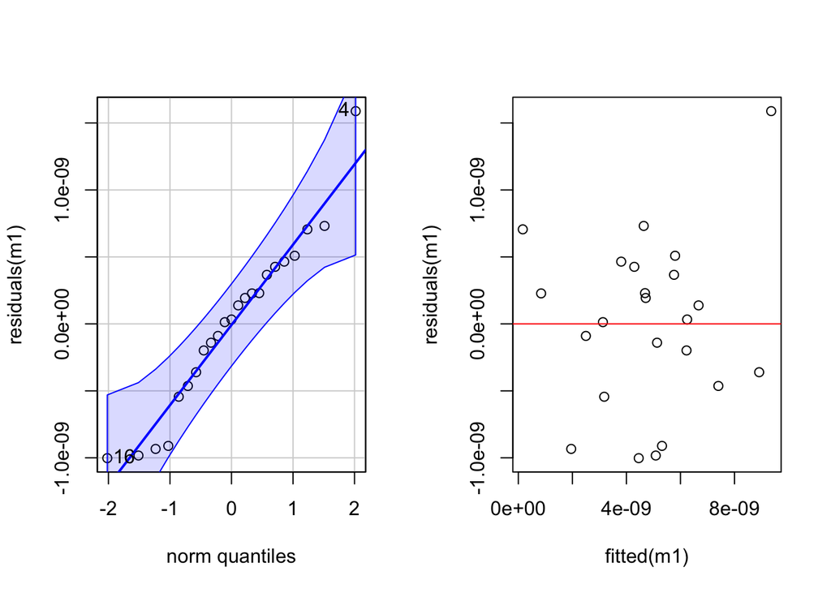

```r
## residuals vs fitted values plot
plot(residuals(m1)~fitted(m1))
abline(a=0, b=0, col="red")
```

```r
#dev.off()
```

## Visualize adsorption constant k using a boxplot

(Figure Fig. 3A)

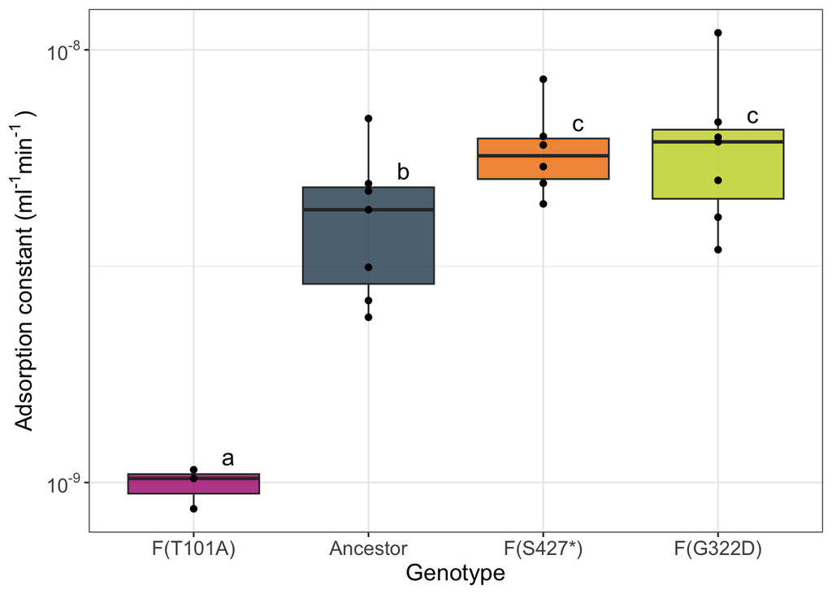

```r
# Rearrange order of genotypes in ascending order
dfslope$Genotype <- factor(dfslope$Genotype , levels=c("T101A", "WT","S427*", "G322D"))

# visualize results of adsorption rate constant
a=ggplot(dfslope,aes(Genotype,k,fill=as.factor(Genotype)))+
  geom_boxplot(alpha=0.8)+ #boxplot
  geom_point()+ # individual adsorption constants as dots
  annotate(geom="text", x=1.2, y=1.15e-09, label="a",
              color="black", size=5)+ # significance letter F(T101A)
    annotate(geom="text", x=2.2, y=5.25e-09, label="b",
              color="black", size=5)+ # significance letter Ancestor
    annotate(geom="text", x=3.2, y=6.8e-09, label="c",
              color="black", size=5)+ # significance letter F(S427*)
    annotate(geom="text", x=4.2, y=7.1e-09, label="c",
              color="black", size=5)+ # significance letter F(G322D)
  scale_y_continuous(trans="log10",
                     labels=trans_format("log10", math_format(10^.x)),
                     breaks=c(1e-09,1e-08))+ # log transformation of y-axis
  scale_x_discrete(breaks=c("T101A","WT","S427*","G322D"),
                   labels=c("F(T101A)","Ancestor","F(S427*)","F(G322D)"))+ # change label of mutants on the x-axis
    scale_fill_manual(values=c("#ae017e","#29485d","#ef7c00","#c6d325"))+ # color setting
  labs(x = "Genotype",
       y = expression(paste("Adsorption constant (ml"^"-1","min"^"-1 ",")")))+ #labels of x and y axis
  theme_bw()+ # plot layout
  theme(legend.position = "none")+ # no legend
  theme(axis.text=element_text(size=12),
        axis.title=element_text(size=14)) # font size
a
```

```r
# Save plot at 600 dpi resolution
#ggsave("adsorption.jpeg", plot = a, dpi = 600, width = 8, height = 6)
```

# Experiment 4: Image analysis of plaque assays

Code used to generate Fig. 3B and Fig. S7 in the manuscript

**READ ME** *Specification of columns in data set*

- **Block**: Experimental block during which the phage isolate was evolved - 0: wild type non-evolved - A: 30-minute transfer experiment - 1: 3-hour transfer experiment
- **Phenotype**: Lysis plaque phenotype forming large plaques (LP) or small plaques (SP)
- **Line**: Selection line phage was evolved in - WT: wild type non-evolved - L3: 30-minute transfer experiment (corresponding to genotype F(T101A)) - L1: 3-hour transfer experiment (corresponding to genotypes F(G322D) [L1]) L4: 3-hour transfer experiment (corresponding to F(S427*) [L4])
- **Image**: Replicate image of individual plaque assay plate, for each phage isolate, four images labelled A to D were taken (corresponding to four independent replicates)
- **Colony**: Individual ID of a lysis plaque on a plaque assay plate selected from the segmentation. Plaques were manually selected, checking for correct recognition of the mask (i.e. intact area, non-connected, individual plaques)
- **Area**: Lysis plaque area in cm^2
- **Distance**: Distance to the plaque periphery in pixels (px)
- **Intensity**: Plaque intensity in pixels (px) at individual distance position within the plaque
- **Intensity_SD**: Standard deviation of pixel intensity
- **ID**: Unique identifier combining block, phenotype, and line

## Load data set

```r
df=read.csv("experiment_4_plaque_image_analysis.csv")

# df consists of 52687 observations and 10 variables
```

## Checking data set

```r
str(df) # structure of columns
```

```
## 'data.frame':    52687 obs. of  10 variables:
##  $ Block       : chr  "0" "0" "0" "0" ...
##  $ Phenotype   : chr  "LP" "LP" "LP" "LP" ...
##  $ Line        : chr  "WT" "WT" "WT" "WT" ...
##  $ Image       : chr  "A" "A" "A" "A" ...
##  $ Colony      : int  8 8 8 8 8 8 8 8 8 8 ...
##  $ Area        : num  0.555 0.555 0.555 0.555 0.555 ...
##  $ Distance    : num  1 1.41 2 2.24 2.83 ...
##  $ Intensity   : num  100 97.2 95.5 94.6 94 ...
##  $ Intensity_SD: num  3.1 1.99 1.81 1.65 1.4 ...
##  $ ID          : chr  "0_LP_WT" "0_LP_WT" "0_LP_WT" "0_LP_WT" ...
```

```r
summary(df) #summary of columns
```

```
##     Block            Phenotype             Line              Image
##  Length:52687       Length:52687       Length:52687       Length:52687
##  Class :character   Class :character   Class :character   Class :character
##  Mode  :character   Mode  :character   Mode  :character   Mode  :character
##
##
##
##      Colony           Area             Distance        Intensity
##  Min.   :  3.0   Min.   :0.001384   Min.   : 1.000   Min.   : 60.00
##  1st Qu.: 19.0   1st Qu.:0.071833   1st Qu.: 5.831   1st Qu.: 76.75
##  Median : 43.0   Median :0.294716   Median :10.296   Median : 83.00
##  Mean   :102.5   Mean   :0.334197   Mean   :12.869   Mean   : 85.62
##  3rd Qu.:117.0   3rd Qu.:0.534672   3rd Qu.:19.105   3rd Qu.: 92.50
##  Max.   :621.0   Max.   :1.524953   Max.   :45.880   Max.   :154.25
##   Intensity_SD          ID
##  Min.   : 0.0000   Length:52687
##  1st Qu.: 0.9428   Class :character
##  Median : 1.7916   Mode  :character
##  Mean   : 2.1207
##  3rd Qu.: 2.8986
##  Max.   :46.1976
```

## **Visualize plaque area**

Code used to generate Fig. 3B

Each colony id corresponds to one measured plaques. Multiple intensity and distance values exist for each colony id but only one area value. To visualize plaque areas, df has to be summarized according to area.

## Summarize data to have only one area value per plaque id

```r
# Make a copy of the df to work with for the area analysis
df1=df

# Subset df1 used for area analysis by removing columns "Distance", "Intensity", and "Intensity_SD"
df1=df1[,-c(7:9)]

# Create unique identifier per colony & image
df1$ColID=paste(df1$ID,df1$Colony,df1$Image,sep="_")

# Summarize data to that only one area per colony id exists
df1=df1 %>%
  group_by(ColID) %>%
  summarise(across(c(Area),mean))

# Seperate unique identifier column "ColID" into individual columnse
df1=separate(df1,col=ColID,into=c("Block","Phenotype","Line","Colony", "Image"),sep="_")

# Convert Phenotype and Line into factors
df1$Phenotype=as.factor(df1$Phenotype)
df1$Line=as.factor(df1$Line)

# Create unique identifier "ID" combining Block, Phenotype, and Line
df1$ID=paste(df1$Block,df1$Phenotype,df1$Line,sep="_")
df1$ID=as.factor(df1$ID)

# Add a column with genotype information
df1$Genotype=NA
# Add genotypes
df1[df1$ID=="0_LP_WT",]$Genotype="WT"
df1[df1$ID=="1_SP_L1",]$Genotype="G322D"
df1[df1$ID=="1_SP_L4",]$Genotype="S427*"
df1[df1$ID=="A_LP_L3",]$Genotype="T101A"

# Convert Genotype into factor
df1$Genotype=as.factor(df1$Genotype)
```

## Visualize plaque area results using a combined violin plot and boxplot (Fig. 3B)

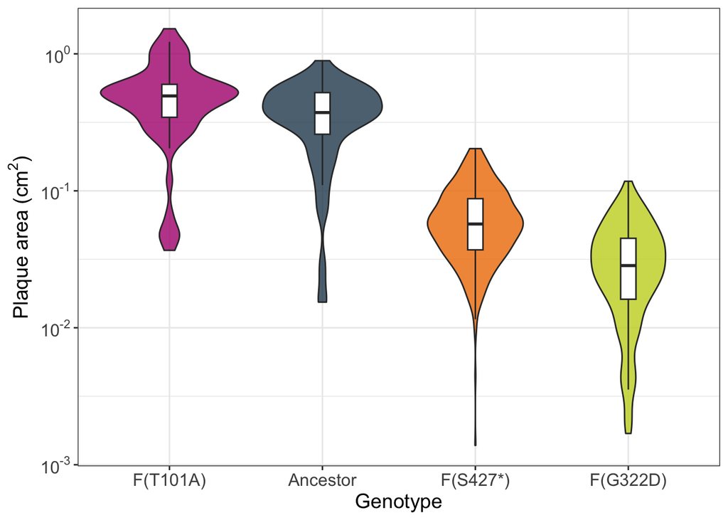

```r
# Rearrange Genotypes based on plaque size in decenting order
df1$Genotype <- factor(df1$Genotype , levels=c("T101A", "WT","S427*", "G322D"))

# Visualize plaque area using a combined box and violin plot (Fig. 3B)
a=ggplot(df1,aes(Genotype,Area, fill=Genotype))+
  geom_violin(alpha=0.8)+ # violin plot
  geom_boxplot(width=0.1, fill="white", outlier.shape=NA)+ # boxplot
scale_y_continuous(trans="log10",
                     labels=trans_format("log10", math_format(10^.x)),
                     breaks=c(1e-03,1e-02,1e-01,1e+00))+ # log scale with exponential y-ticks
  scale_x_discrete(breaks=c("T101A","WT","S427*","G322D"),
                   labels=c("F(T101A)","Ancestor","F(S427*)","F(G322D)"))+ # Change x labels
    scale_fill_manual(values=c("#ae017e","#29485d","#ef7c00","#c6d325"))+ #setting colors of violin plot
  labs(x = "Genotype",
       y = expression(paste("Plaque area (cm"^"2",")")))+ # labels of x and y axis
  theme_bw()+ # plot layout
  theme(legend.position = "none")+ # remove figure legend
  theme(axis.text=element_text(size=12),
        axis.title=element_text(size=14)) # set font size
a
```

```r
# Save plot at high resolution resolution
#ggsave("plaque_area.jpeg", plot = a, dpi = 600, width = 8, height = 6)
```

## Summary data for plaque area

```r
# Summary of total number of plaques analyzed for each genotype
summary(df1)
```

```
##     Block           Phenotype Line        Colony             Image
##  Length:870         LP:136    L1:303   Length:870         Length:870
##  Class :character   SP:734    L3: 60   Class :character   Class :character
##  Mode  :character             L4:431   Mode  :character   Mode  :character
##                               WT: 76
##
##
##       Area                ID       Genotype
##  Min.   :0.001384   0_LP_WT: 76   T101A: 60
##  1st Qu.:0.028572   1_SP_L1:303   WT   : 76
##  Median :0.051452   1_SP_L4:431   S427*:431
##  Mean   :0.112703   A_LP_L3: 60   G322D:303
##  3rd Qu.:0.095175
##  Max.   :1.524953
```

```r
# F(G322D): 303
# F(S427*): 431
# F(T101A): 60
# ancestor: 76

# Calculate mean and standard error for plaque area of each genotype
## Ancestor
mean(df1[df1$Genotype=="WT",]$Area) # 0.375
```

```
## [1] 0.3749175
```

```r
std.error(df1[df1$Genotype=="WT",]$Area) # 0.021
```

```
## [1] 0.02140839
```

```r
## F(T101A)
mean(df1[df1$Genotype=="T101A",]$Area) #0.518
```

```
## [1] 0.5184235
```

```r
std.error(df1[df1$Genotype=="T101A",]$Area) # 0.039
```

```
## [1] 0.0391119
```

```r
## F(G322D)
mean(df1[df1$Genotype=="G322D",]$Area) # 0.033
```

```
## [1] 0.03278611
```

```r
std.error(df1[df1$Genotype=="G322D",]$Area) # 0.001
```

```
## [1] 0.001302967
```

```r
## F(S427*)
mean(df1[df1$Genotype=="S427*",]$Area) #0.066
```

```
## [1] 0.06616785
```

```r
std.error(df1[df1$Genotype=="S427*",]$Area) #0.002
```

```
## [1] 0.00189727
```

## ** Visualize plaque turbidity**

Code for supplementary figure Fig. S7

## Calculate mean intensity and area

```r
# Make a copy of df
df2=df

# Create unique identifier per colony & image
df2$ColID=paste(df2$ID,df2$Colony,df2$Image,sep="_")

# Summarize data to that only one area per colony id exists
df2=df2 %>%
  group_by(ColID) %>%
  summarise(across(c(Area, Intensity),mean))

# Seperate unique identifier column "ColID" into individual columnse
df2=separate(df2,col=ColID,into=c("Block","Phenotype","Line","Colony", "Image"),sep="_")

# Convert Phenotype and Line into factors
df2$Phenotype=as.factor(df2$Phenotype)
df2$Line=as.factor(df2$Line)

# Create unique identifier "ID" combining Block, Phenotype, and Line
df2$ID=paste(df2$Block,df2$Phenotype,df2$Line,sep="_")
df2$ID=as.factor(df2$ID)

# Add a column with genotype information
df2$Genotype=NA
# Add genotypes
df2[df2$ID=="0_LP_WT",]$Genotype="Ancestor"
df2[df2$ID=="1_SP_L1",]$Genotype="F(G322D)"
df2[df2$ID=="1_SP_L4",]$Genotype="F(S427*)"
df2[df2$ID=="A_LP_L3",]$Genotype="F(T101A)"

# Convert Genotype into factor
df2$Genotype=as.factor(df2$Genotype)
```

## Visualize plaque turbidity using a density plot (Fig.S7)

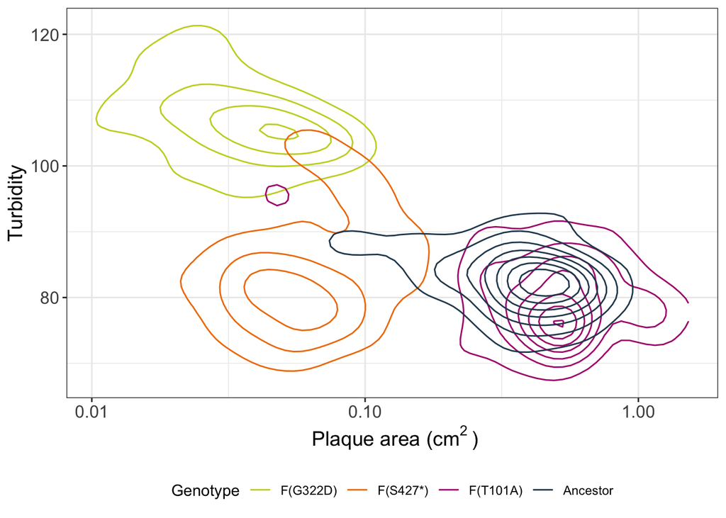

```r
# Set levels of genotypes form highest to lowest turbidty
df2$Genotype <- factor(df2$Genotype , levels=c("F(G322D)", "F(S427*)","F(T101A)", "Ancestor"))

# Plot results using a density plot
x=ggplot(df2,aes(x=Area,y=Intensity,color=Genotype)) +
  geom_density_2d()+ # density plot with concentric areas
  scale_x_continuous(trans="log10")+ # log transform area axis
        scale_color_manual(values=c("#c6d325","#ef7c00","#ae017e","#29485d"))+ # set color palette
  labs(x = expression(paste(" Plaque area (cm"^"2 ",")")),
       y="Turbidity")+ # labels of x- and y-axis
  theme_bw()+ # plot layout
  theme(legend.position = "bottom")+ # legend position
  theme(axis.text=element_text(size=12),
        axis.title=element_text(size=14)) # font size
x
```

```r
# Save image at high resolution as jpeg file
#ggsave("turbidity.jpeg", plot = x, dpi = 600, width = 8, height = 6)
```

# Experiment 5: Free phages transferred during 30-min transfer experiment

Code used to generate Fig. 4D and Fig. S9 in the manuscript

**READ ME** *Specification of columns in data set*

- **Replicate**: Biological replicates of the assay. In total, 3 biological replicates were done. For each replicate, a different bacterial culture initiated from an individual colony was used.

-**Treatment**: Treatment Filtration: Samples were sterile filtered using a 0.2 µm filter to remove bacteria and phages still inside bacterial hosts

-**Transfer**: Transfer identity: Transfers T1, T2, T3, and T4 were individual 30-minute transfers. For transfer T1, phage lysate was used to inoculate bacterial hosts at an MOI input of ~0.1. For the three consecutive transfers, 100 µl of phage-bacteria mix was transferred onto fresh, susceptible ancestral bacteria cells. The same protocol was used in Experiment 2: 30-min transfer regime.

-**Line**: Genotype used to initiate the transfer - WT: ancestral wild-type phage genotype, large plaque former - T101A: mutant T101A forming large plaques, evolved during 30-minute transfers in Experiment 2: 30-min transfer regime.

-**CFU**: Colony-forming units of the ancestral E. coli C culture in exponential phase at the moment of infection initiation

-**Dilution_CFU**: Plating dilution used to plate CFUs; 100 µl of this dilution was plated for colony counts unless stated otherwise.

-**CFU_ml**: Colony-forming units in ml, calculated by CFU*CFU_dilution*10 (because 100 µl were plated)

-**PFU_LP_1**: Plaque-forming units of the large-plaque phenotype for each sample of replicate plating 1

-**Dilution_1**: Plating dilution used for PFU counts, 100 µl of plating dilution was plated for plaque counting of replicate plating 1

-**PFU_LP_2**: Plaque-forming units of the large-plaque phenotype for each sample of replicate plating 2

-**Dilution_2**: Plating dilution used for PFU counts, 100 µl of plating dilution was plated for plaque counting of replicate plating 2

-**PFU_LP_3**: Plaque-forming units of the large-plaque phenotype for each sample of replicate plating 3

-**Dilution_3**: Plating dilution used for PFU counts, 100 µl of plating dilution was plated for plaque counting of replicate plating 3

-**PFU_ml_LP1**: Plaque-forming units per ml of large plaque phenotype calculated as PFU*dilution_1*10 (because 100 µl were plated) of replicate plating 1

-**PFU_ml_LP2**: Plaque-forming units per ml of large plaque phenotype calculated as PFU*dilution_1*10 (because 100 µl were plated) of replicate plating 2

-**PFU_ml_LP3**: Plaque-forming units per ml of large plaque phenotype calculated as PFU*dilution_1*10 (because 100 µl were plated) of replicate plating 3

-**Median_PFU_ml**: Median large plaque PFU per ml calculated based on phage concentrations of the three replicate platings

-**Median_WT**: Median of titering for the wild type taken from column “Median_PFU_ml” used to calculate the ratio between free phages of mutant F(T101A) and the ancestor

## Load data set

```r
df=read.csv("experiment_5_30min_free_phages.csv")

# df has 24 observations and 18 variables
```

## Checking data set

```r
str(df) # structure of data columns
```

```
## 'data.frame':    24 obs. of  18 variables:
##  $ Replicate    : int  1 1 1 1 1 1 1 1 2 2 ...
##  $ Treatment    : chr  "Filtration" "Filtration" "Filtration" "Filtration" ...
##  $ Transfer     : chr  "T1" "T2" "T3" "T4" ...
##  $ Line         : chr  "T101A" "T101A" "T101A" "T101A" ...
##  $ CFU          : int  148 136 78 135 148 136 78 135 75 73 ...
##  $ Dilution_CFU : num  1e+05 1e+05 1e+05 1e+05 1e+05 1e+05 1e+05 1e+05 1e+05 1e+05 ...
##  $ CFU_ml       : num  1.48e+08 1.36e+08 7.80e+07 1.35e+08 1.48e+08 1.36e+08 7.80e+07 1.35e+08 7.50e+07 7.30e+07 ...
##  $ PFU_LP_1     : int  14 26 194 139 26 97 168 145 53 170 ...
##  $ Dilution_1   : num  1e+06 1e+07 1e+06 1e+06 1e+06 1e+06 1e+06 1e+06 1e+06 1e+07 ...
##  $ PFU_LP_2     : int  70 28 23 95 60 96 15 78 49 113 ...
##  $ Dilution_2   : num  1e+05 1e+07 1e+07 1e+06 1e+05 1e+06 1e+07 1e+06 1e+06 1e+07 ...
##  $ PFU_LP_3     : int  80 26 21 95 20 80 60 47 52 96 ...
##  $ Dilution_3   : num  1e+05 1e+07 1e+07 1e+06 1e+05 1e+06 1e+06 1e+06 1e+06 1e+07 ...
##  $ PFU_ml1      : num  1.40e+08 2.60e+09 1.94e+09 1.39e+09 2.60e+08 ...
##  $ PFU_ml2      : num  7.0e+07 2.8e+09 2.3e+09 9.5e+08 6.0e+07 ...
##  $ PFU_ml3      : num  8.0e+07 2.6e+09 2.1e+09 9.5e+08 2.0e+07 8.0e+08 6.0e+08 4.7e+08 5.2e+08 9.6e+09 ...
##  $ Median_PFU_ml: num  8.0e+07 2.6e+09 2.1e+09 9.5e+08 6.0e+07 ...
##  $ Median_WT    : num  6.0e+07 9.6e+08 1.5e+09 7.8e+08 6.0e+07 9.6e+08 1.5e+09 7.8e+08 2.9e+08 7.3e+09 ...
```

```r
summary(df) # summary of data columns
```

```
##    Replicate  Treatment           Transfer             Line
##  Min.   :1   Length:24          Length:24          Length:24
##  1st Qu.:1   Class :character   Class :character   Class :character
##  Median :2   Mode  :character   Mode  :character   Mode  :character
##  Mean   :2
##  3rd Qu.:3
##  Max.   :3
##       CFU         Dilution_CFU       CFU_ml             PFU_LP_1
##  Min.   : 73.0   Min.   :1e+05   Min.   : 73000000   Min.   : 14.00
##  1st Qu.: 96.0   1st Qu.:1e+05   1st Qu.: 96000000   1st Qu.: 25.25
##  Median :135.5   Median :1e+05   Median :135500000   Median : 43.50
##  Mean   :150.6   Mean   :1e+05   Mean   :150583333   Mean   : 72.12
##  3rd Qu.:150.8   3rd Qu.:1e+05   3rd Qu.:150750000   3rd Qu.:109.00
##  Max.   :354.0   Max.   :1e+05   Max.   :354000000   Max.   :194.00
##    Dilution_1           PFU_LP_2        Dilution_2          PFU_LP_3
##  Min.   :  1000000   Min.   : 15.00   Min.   :1.00e+05   Min.   : 15.00
##  1st Qu.:  1000000   1st Qu.: 22.75   1st Qu.:1.00e+06   1st Qu.: 25.25
##  Median : 10000000   Median : 45.50   Median :1.00e+07   Median : 45.00
##  Mean   : 17125000   Mean   : 50.96   Mean   :1.78e+07   Mean   : 52.54
##  3rd Qu.: 10000000   3rd Qu.: 75.00   3rd Qu.:1.00e+07   3rd Qu.: 80.00
##  Max.   :100000000   Max.   :113.00   Max.   :1.00e+08   Max.   :128.00
##    Dilution_3           PFU_ml1             PFU_ml2
##  Min.   :   100000   Min.   :1.400e+08   Min.   :6.000e+07
##  1st Qu.:  1000000   1st Qu.:8.600e+08   1st Qu.:7.075e+08
##  Median : 10000000   Median :2.270e+09   Median :2.550e+09
##  Mean   : 17425000   Mean   :5.562e+09   Mean   :5.272e+09
##  3rd Qu.: 10000000   3rd Qu.:8.100e+09   3rd Qu.:7.625e+09
##  Max.   :100000000   Max.   :1.900e+10   Max.   :2.200e+10
##     PFU_ml3          Median_PFU_ml         Median_WT
##  Min.   :2.000e+07   Min.   :6.000e+07   Min.   :6.000e+07
##  1st Qu.:5.075e+08   1st Qu.:7.150e+08   1st Qu.:6.575e+08
##  Median :2.650e+09   Median :2.350e+09   Median :1.800e+09
##  Mean   :5.344e+09   Mean   :5.366e+09   Mean   :3.560e+09
##  3rd Qu.:9.375e+09   3rd Qu.:8.700e+09   3rd Qu.:5.425e+09
##  Max.   :2.300e+10   Max.   :2.200e+10   Max.   :1.280e+10
```

```r
# Turn line into a factor
df$Line=as.factor(df$Line)
```

## Calculate ratio between WT and T101

```r
df$ratio=df$Median_PFU_ml/df$Median_WT
# for WT, ratio should be 1, check if this is true
summary(df[df$Line=="WT",]$ratio)
```

```
##    Min. 1st Qu.  Median    Mean 3rd Qu.    Max.
##       1       1       1       1       1       1
```

## Calculate mean and st between ratios of T101A/WT for each transfer

```r
# Remove all WT (ratio value=1)
df1=df[df$Line!="WT",]

# Create a column for ratio mean and se
df1$mean=NA
df1$st.error=NA

# Mean and standard error of all transfer T1 for three replicates
mean(df1[df1$Transfer=="T1",]$ratio) #1.51
```

```
## [1] 1.505914
```

```r
std.error(df1[df1$Transfer=="T1",]$ratio) #0.14
```

```
## [1] 0.1445667
```

```r
## add values to table
df1[df1$Transfer=="T1",]$mean=1.51
df1[df1$Transfer=="T1",]$st.error=0.14

# Mean and standard error of all transfer T2 for three replicates
mean(df1[df1$Transfer=="T2",]$ratio) #1.99
```

```
## [1] 1.991676
```

```r
std.error(df1[df1$Transfer=="T2",]$ratio) #0.36
```

```
## [1] 0.3617051
```

```r
## add values to table
df1[df1$Transfer=="T2",]$mean=1.99
df1[df1$Transfer=="T2",]$st.error=0.36

# Mean and standard error of all transfer T3 for three replicates
mean(df1[df1$Transfer=="T3",]$ratio) #1.84
```

```
## [1] 1.836898
```

```r
std.error(df1[df1$Transfer=="T3",]$ratio) #0.22
```

```
## [1] 0.2184878
```

```r
## add values to table
df1[df1$Transfer=="T3",]$mean=1.84
df1[df1$Transfer=="T3",]$st.error=0.22

# Mean and standard error of all transfer T4 for three replicates
mean(df1[df1$Transfer=="T4",]$ratio) #2.47
```

```
## [1] 2.477411
```

```r
std.error(df1[df1$Transfer=="T4",]$ratio) #0.88
```

```
## [1] 0.8779285
```

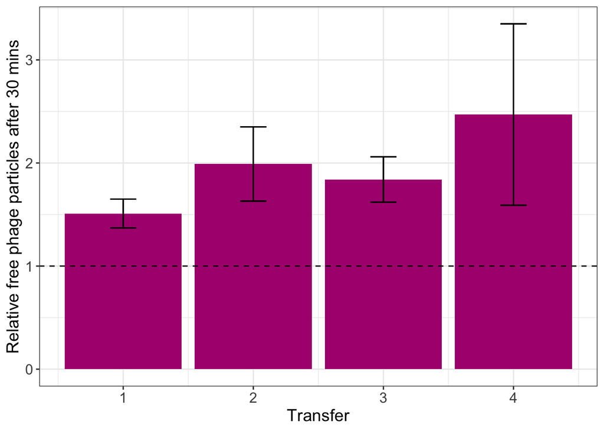

```r
## add values to table
df1[df1$Transfer=="T4",]$mean=2.47
df1[df1$Transfer=="T4",]$st.error=0.88

# Add transfer as individual number
df1$no_transfer=NA
df1[df1$Transfer=='T1',]$no_transfer=1
df1[df1$Transfer=='T2',]$no_transfer=2
df1[df1$Transfer=='T3',]$no_transfer=3
df1[df1$Transfer=='T4',]$no_transfer=4

# Visualize phage ratios compared to wild type in a bar plot (Fig. 4D)
a=ggplot(df1,aes(no_transfer, mean,fill=Line))+
  geom_bar(stat="identity", position=position_dodge())+ # bar chart vertical
  geom_errorbar(aes(ymin=mean-st.error, ymax=mean+st.error), width=.2,
                 position=position_dodge(.9))+ # add error bars
    scale_fill_manual(values=c("#ae017e"))+ # set colors of bars
  geom_hline(yintercept=1,linetype="dashed", color="black")+ # horizontal line at 1 (indicating ratio frequency of wild type )
  xlab("Transfer")+ # label x-axis
    ylab("Relative free phage particles after 30 mins")+ # label y-axis
  theme_bw()+ # plot layout
  theme(legend.position = "none")+
    theme(axis.text=element_text(size=12),
        axis.title=element_text(size=14)) # remove legend and set font size
a
```

```r
# Save plot at high resolution (Fig 4 D)
#ggsave("free_phages.jpeg", plot = a, dpi = 600, width = 8, height = 6)
```

## Visualization of phage titers of mutant F(T101A) before and after every 30-min transfer to visualize phage population growth during a 30-min infection period

Code used to generate Fig. S9 in the manuscript (figure was added after review)

# Subset df to only T101A mutant data

```r
df_T101A=df[df$Line=="T101A",]

# Select only columns "Replicate", "Transfer", and "Median_PFU_ml"
df_T101A=df_T101A[,c(1,3,17)]

# Merge Replicate and Transfer to an individual ID
df_T101A$ID=paste(df_T101A$Replicate,df_T101A$Transfer,sep="_")
```

# Reneame column “Median_PFU_ml” to “Titer_output” and create a column named “Titer_input”

```r
# Rename column "Median_PFU"
names(df_T101A)[3]="Titer_output"

# Create new column
df_T101A$Titer_input=NA
```

# Caclulate and fill titer input column

```r
# For T1 titer input is 1e+07 PFU/ml set at the start of the experiment for all three replicates
df_T101A[df_T101A$Transfer=="T1",]$Titer_input=1e+07

# Caclulations for input titers into T2 based on T1 output titers
## For all transfers T2-T4, 100 µl of the phage output concentration from the previous transfer were added to 5 ml bacteria

## Calculation for the input phage concentration conc(input)=(0.1*conc(output))/5
# Calculation input T2
## Replicate 1
df_T101A[df_T101A$ID=="1_T2",]$Titer_input=(df_T101A[df_T101A$ID=="1_T1",]$Titer_output*0.1)/5

## Replicate 2
df_T101A[df_T101A$ID=="2_T2",]$Titer_input=(df_T101A[df_T101A$ID=="2_T1",]$Titer_output*0.1)/5

## Replicate 3
df_T101A[df_T101A$ID=="3_T2",]$Titer_input=(df_T101A[df_T101A$ID=="3_T1",]$Titer_output*0.1)/5

# Calculation input T3
## Replicate 1
df_T101A[df_T101A$ID=="1_T3",]$Titer_input=(df_T101A[df_T101A$ID=="1_T2",]$Titer_output*0.1)/5

## Replicate 2
df_T101A[df_T101A$ID=="2_T3",]$Titer_input=(df_T101A[df_T101A$ID=="2_T2",]$Titer_output*0.1)/5

## Replicate 3
df_T101A[df_T101A$ID=="3_T3",]$Titer_input=(df_T101A[df_T101A$ID=="3_T2",]$Titer_output*0.1)/5

# Calculation input T4
## Replicate 1
df_T101A[df_T101A$ID=="1_T4",]$Titer_input=(df_T101A[df_T101A$ID=="1_T3",]$Titer_output*0.1)/5

## Replicate 2
df_T101A[df_T101A$ID=="2_T4",]$Titer_input=(df_T101A[df_T101A$ID=="2_T3",]$Titer_output*0.1)/5

## Replicate 3
df_T101A[df_T101A$ID=="3_T4",]$Titer_input=(df_T101A[df_T101A$ID=="3_T3",]$Titer_output*0.1)/5

# export csv
#write.csv(df_T101A,"df_T101A.csv")
```

# Rearrange df_T101A from wide to long for visualization

```r
df_long <- df_T101A %>%
  pivot_longer(
    cols = c(Titer_input, Titer_output),  # Specify the columns to reshape
    names_to = "Treatment",              # New column for treatment type
    values_to = "Titer",                 # New column for titer values
    names_ptypes = list(treatment = factor())  # Optional: ensure treatment is a factor
  )

# Rename treatment to "input" and "output"
df_long[df_long$Treatment=="Titer_input",]$Treatment="input"
df_long[df_long$Treatment=="Titer_output",]$Treatment="output"

# Create unique ID_new column merging Transfer and Treatment
df_long$ID_new=paste(df_long$Transfer,df_long$Treatment,sep="_")

write.csv(df_long,"df_long_final.csv")
```

# Visualize the input vs output titer results

*Code to generate figure Fig. S9*

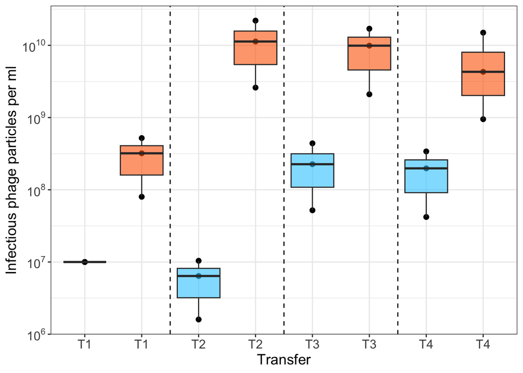

```r
x=ggplot(df_long,aes(ID_new,Titer, group=ID_new, fill=Treatment))+
  geom_point(size=2)+
  geom_boxplot(alpha=0.6)+
  scale_y_continuous(trans="log10",
                     labels=trans_format("log10", math_format(10^.x)),
                     breaks=c(1e+06,1e+07,1e+08, 1e+09,1e+10) )+#y-axis log-transformation
  scale_x_discrete(limits=c("T1_input","T1_output","T2_input","T2_output","T3_input","T3_output","T4_input","T4_output"),
                   labels=c("T1","T1","T2","T2","T3","T3","T4","T4"))+
  scale_fill_manual(values=c("#33CCFF","#FF6600"))+
  geom_vline(xintercept = c(2.5,4.5,6.5), linetype="dashed")+
  xlab("Transfer")+ # label x-axis
  ylab("Infectious phage particles per ml")+ # label y-axis
  theme_bw()+ # plot layout
  theme(legend.position = "bottom")+ # legend position
  theme(axis.text=element_text(size=12),
        axis.title=element_text(size=14),
        legend.position = "none")# Text size
x
```

```r
# Save at high resolution
#ggsave("T101A_Amplification.jpeg", plot = x, dpi = 600, width = 10, height = 6)
```

# Experiment 6: Decay analysis

Code used to generate Fig. 5B and Fig. S12 in the manuscript

**READ ME** *Specification of columns in data set*

- **Sampling_time_min**: Sampling time in minutes, phages were extracted by chloroform extraction
- **Genotype**: Genotypes of phage isolates - WT: wild-type large plaque former - T101A: large plaque mutant evolved from WT using 30-min transfers - G322D: small plaque mutant evolved from WT using 3 hour transfers - S427*: small plaque mutant evolved from WT using 3 hour transfers
- **CFU**: colony-forming units of E. coli C exponential phase culture at the moment of phage infection
- **Dilution_CFU**: Plating dilution used to plate CFUs; 100 µl of this dilution was plated for colony counts unless stated otherwise.
- **CFU_ml**: Colony-forming units per ml calculated by CFU*CFU_dilution*10; factor *10 because 100 µl of CFU_dilution was plated
- **PFU**: Plaque-forming units
- **Dilution_PFU**: Plating dilution used for PFU counts, 100 µl of plating dilution was plated for plaque counting
- **PFU_ml**: Plaque-forming units per ml calculated by PFU*PFU_dilution*10; factor *10 because 100 µl of PFU_dilution was plated

## Load data set

```r
df=read.csv("experiment_6_decay_analysis.csv")

# df contains 40 observations of 8 variables
```

## Checking data set

```r
str(df) # structure of columns
```

```
## 'data.frame':    40 obs. of  8 variables:
##  $ Sampling_time_min: int  30 30 30 30 60 60 60 60 90 90 ...
##  $ Genotype         : chr  "WT" "G322D" "S427*" "T101A" ...
##  $ CFU              : int  108 108 108 108 108 108 108 108 108 108 ...
##  $ Dilution_CFU     : num  1e+05 1e+05 1e+05 1e+05 1e+05 1e+05 1e+05 1e+05 1e+05 1e+05 ...
##  $ CFU_ml           : num  1.08e+08 1.08e+08 1.08e+08 1.08e+08 1.08e+08 1.08e+08 1.08e+08 1.08e+08 1.08e+08 1.08e+08 ...
##  $ PFU              : int  62 72 245 101 81 128 138 48 40 147 ...
##  $ Dilution_PFU     : num  1e+07 1e+07 1e+07 1e+06 1e+08 1e+08 1e+08 1e+08 1e+08 1e+08 ...
##  $ PFU_ml           : num  6.20e+09 7.20e+09 2.45e+10 1.01e+09 8.10e+10 ...
```

```r
summary(df) #summary of columns
```

```
##  Sampling_time_min   Genotype              CFU       Dilution_CFU
##  Min.   : 30       Length:40          Min.   :108   Min.   :1e+05
##  1st Qu.: 90       Class :character   1st Qu.:108   1st Qu.:1e+05
##  Median :165       Mode  :character   Median :108   Median :1e+05
##  Mean   :165                          Mean   :108   Mean   :1e+05
##  3rd Qu.:240                          3rd Qu.:108   3rd Qu.:1e+05
##  Max.   :300                          Max.   :108   Max.   :1e+05
##      CFU_ml              PFU          Dilution_PFU           PFU_ml
##  Min.   :1.08e+08   Min.   : 15.00   Min.   :  1000000   Min.   :1.010e+09
##  1st Qu.:1.08e+08   1st Qu.: 48.00   1st Qu.: 10000000   1st Qu.:5.975e+09
##  Median :1.08e+08   Median : 83.50   Median :100000000   Median :4.400e+10
##  Mean   :1.08e+08   Mean   : 97.25   Mean   : 65350000   Mean   :6.710e+10
##  3rd Qu.:1.08e+08   3rd Qu.:139.25   3rd Qu.:100000000   3rd Qu.:1.190e+11
##  Max.   :1.08e+08   Max.   :245.00   Max.   :100000000   Max.   :2.230e+11
```

```r
# Convert genotype into factor
df$Genotype=as.factor(df$Genotype)
```

## Add plaque phenotype column to the df

```r
# Add plaque phenotype column to the df frame
df$Phenotype=NA
df[df$Genotype=="WT",]$Phenotype="LP"
df[df$Genotype=="T101A",]$Phenotype="LP"
df[df$Genotype=="G322D",]$Phenotype="SP"
df[df$Genotype=="S427*",]$Phenotype="SP"

# Convert phenotype into a factor
df$Phenotype=as.factor(df$Phenotype)
```

## Relable Genotypes to clarify that all mutations are found in protein F in a new column called “Label” for plotting

```r
# Add Genotypes as Labels including the protein in which mutation occurs
df$Label=NA
df[df$Genotype=="G322D",]$Label="F(G322D)"
df[df$Genotype=="S427*",]$Label="F(S427*)"
df[df$Genotype=="T101A",]$Label="F(T101A)"
df[df$Genotype=="WT",]$Label="Ancestor"

# Convert Label into factor
df$Label=as.factor(df$Label)
```

## ** Visualize phage population dynamics during long infection time**

(Supplementary Figure S12)

## Visualization using a dotplot

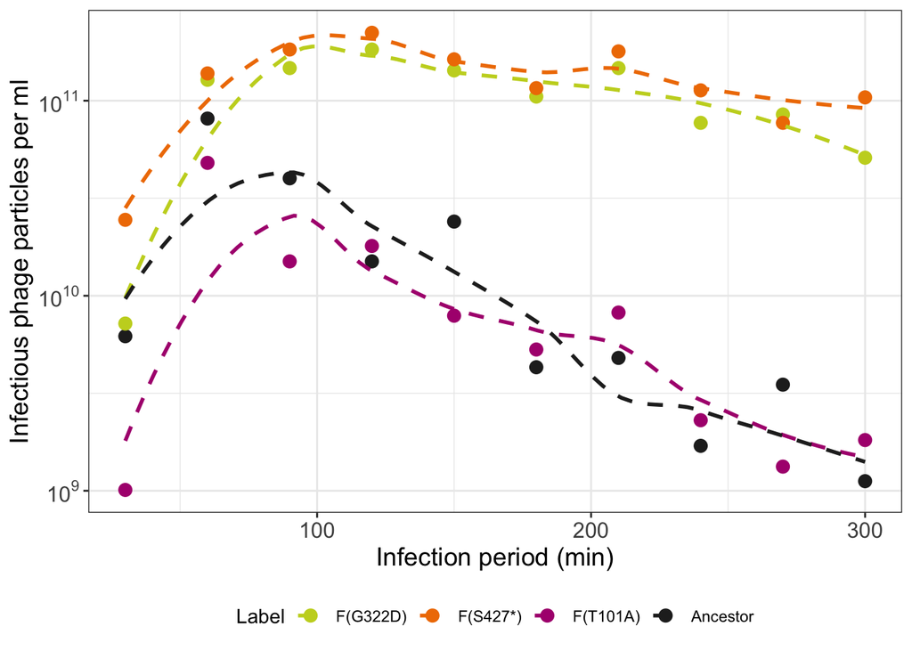

```r
# Rearrange Label to the corresponding color code
df$Label <- factor(df$Label , levels=c("F(G322D)", "F(S427*)","F(T101A)", "Ancestor"))

# Plotting population dynamics throughout infection period
x=ggplot(df,aes(Sampling_time_min,PFU_ml,group=Label, color=Label))+
  geom_point(size=3)+ # dotplot
  geom_smooth(method="loess", se=F, linetype="dashed")+ #model fit loess
 scale_y_continuous(trans="log10",
                    labels=trans_format("log10", math_format(10^.x)),
                     breaks=c(1e+09,1e+10,1e+11) )+ #y-axis log-transformation
  scale_color_manual(values=c("#c6d325","#ef7c00","#ae017e","#252525"))+ # setting colors
  xlab("Infection period (min)")+ # label x-axis
  ylab("Infectious phage particles per ml")+ # label y-axis
  theme_bw()+ # plot layout
  theme(legend.position = "bottom")+ # legend position
  theme(axis.text=element_text(size=12),
        axis.title=element_text(size=14)) # font size
x
```

```r
# Save plot as high resolution jpeg file
# ggsave("supplementary_pop_dyn.jpeg", plot = x, dpi = 600, width = 8, height = 6)
```

## **Calculate and visualize phage decay**

(Figure Fig 5B)

## Calculate ratio decay at individual time step / productivity peak

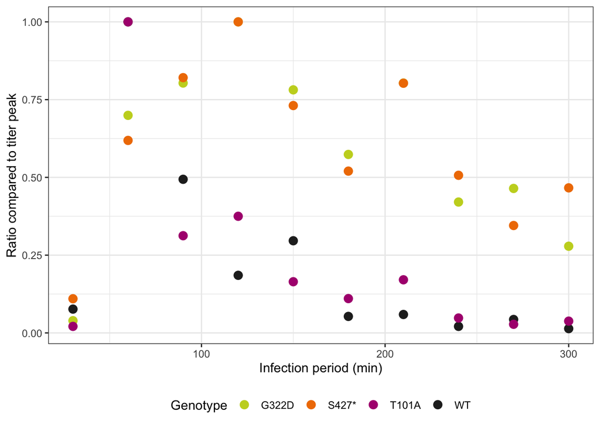

```r
# Determine peak titer for each genotype and the time point of the peak
df$Peak=NA
df[df$Genotype=="WT",]$Peak=8.10e+10 # peak at 60 min p.i.
df[df$Genotype=="T101A",]$Peak=4.80e+10 #peak at 60 min p.i
df[df$Genotype=="G322D",]$Peak=1.83e+11 # peak at 120 min p.i.
df[df$Genotype=="S427*",]$Peak=2.23e+11 # peak at 120 min p.i.

# Calculate ratio between each time step and peak
df$Ratio=df$PFU_ml/df$Peak

# Create unique identifier combining sampling time and genotype
df$ID=paste(df$Sampling_time_min,df$Genotype,sep="_")

# Plot growth and decay ratios using a dot plot
ggplot(df,aes(Sampling_time_min,Ratio,group=Genotype,color=Genotype))+
  geom_point(size=3)+ # dot plot
  scale_color_manual(values=c("#c6d325","#ef7c00","#ae017e","#252525"))+ # set color palette
  xlab("Infection period (min)")+ # label x-axis
  ylab("Ratio compared to titer peak")+ # label y-axis
  theme_bw()+ # plot layout
  theme(legend.position = "bottom") # legend position
```

## Prepare dataset for model fititng

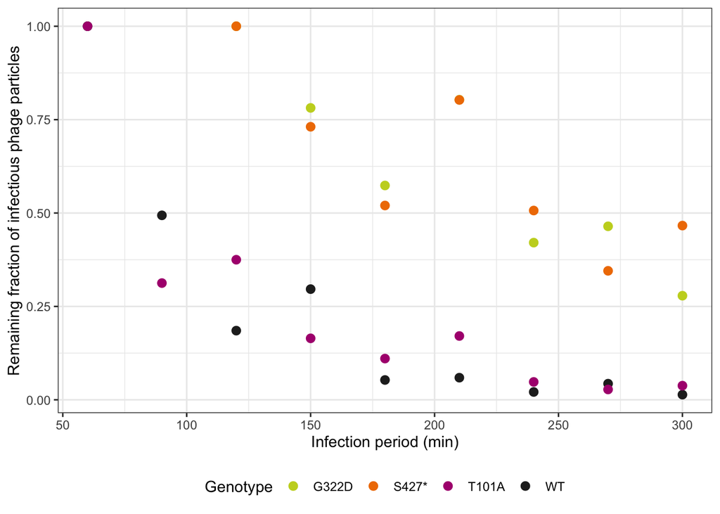

```r
# Remove time points between start and peak phage titers to only capture decay period
data1=df[df$Sampling_time_min!=30,]
data1=data1[data1$ID!="60_G322D",]
data1=data1[data1$ID!="60_S427*",]
data1=data1[data1$ID!="90_G322D",]
data1=data1[data1$ID!="90_S427*",]

# Plot ratios during the decay period
ggplot(data1[data1$Sampling_time_min<310,],aes(Sampling_time_min,Ratio,group=Genotype,color=Genotype))+
  geom_point(size=2.5)+ # dot plot
  scale_color_manual(values=c("#c6d325","#ef7c00","#ae017e","#252525"))+ # set color palette
  xlab("Infection period (min)")+ # label x-axis
  ylab("Remaining fraction of infectious phage particles")+ # label y-axis
  theme_bw()+ # plot layout
  theme(legend.position = "bottom") # legend position
```

```r
# ==> Phage decay seems to follow an exponential decay function
```

## Fitting decay curve to ancestor

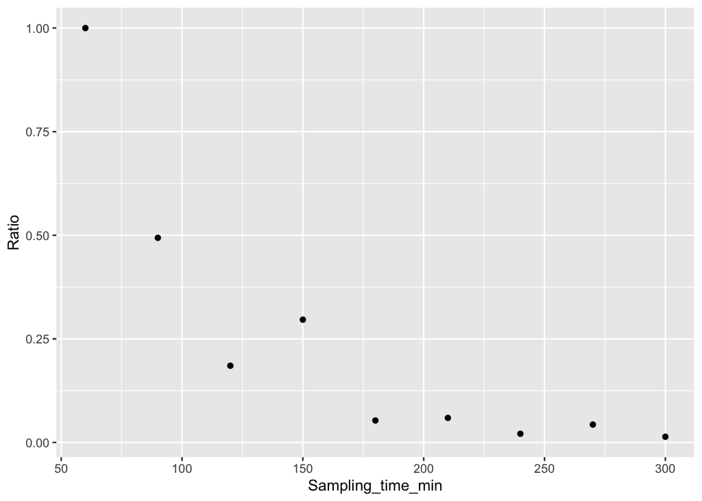

```r
# Plot WT decay using a dotplot
ggplot(data1[data1$Genotype=="WT",], aes(Sampling_time_min,Ratio))+
  geom_point()
```

```r
# x and y vector extracted from the WT dataset for model fitting
x1=data1[data1$Genotype=="WT",]$Sampling_time_min
y1=data1[data1$Genotype=="WT",]$Ratio

# Compare Linear model with exponential decay model
## Linear model
a1=lm(y1~x1)

## Exponential model
### Select appropriate starting values: Select an approximate $\theta$, since theta must be lower than min(y), and greater than zero
theta.0 <- min(y1) * 0.5

### Estimate the rest parameters using a linear model
model.0 <- lm(log(y1 - theta.0) ~ x1)
alpha.0 <- exp(coef(model.0)[1])
beta.0 <- coef(model.0)[2]

### Starting parameters
start<-list(alpha = alpha.0, beta = beta.0)

a2<- nls(y1 ~ alpha * exp(beta * x1) ,  start = start)

## Summary list AIC and BIC for model comparison
AIC(a1,a2)
```

```
##    df         AIC
## a1  3   0.3392432
## a2  3 -18.7277255
```

```r
# df         AIC
#a1  3   0.3392432
#a2  3 -18.7277255

BIC(a1,a2)
```

```
##    df         BIC
## a1  3   0.9309169
## a2  3 -18.1360518
```

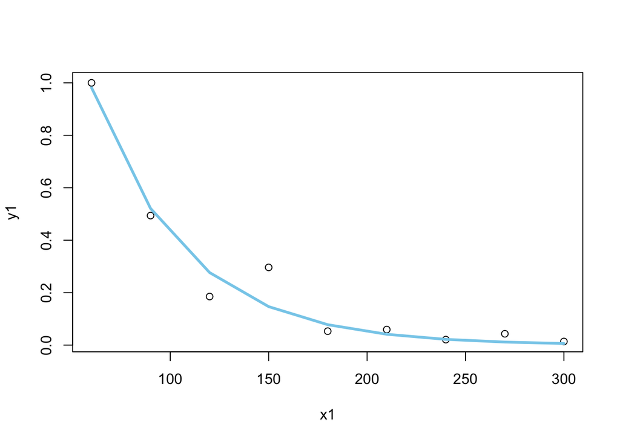

```r
# df         BIC
#a1  3   0.9309169
#a2  3 -18.1360518

# ==> model a2 is best fit

## Plot predicted and measured values
plot(x1,y1)
lines(x1, predict(a2, list(x = x1)), col = 'skyblue', lwd = 3)
```

```r
## Get parameter estimates
summary(a2)
```

```
##
## Formula: y1 ~ alpha * exp(beta * x1)
##
## Parameters:
##        Estimate Std. Error t value Pr(>|t|)
## alpha  3.483344   0.708369   4.917 0.001719 **
## beta  -0.021112   0.002708  -7.797 0.000107 ***
## ---
## Signif. codes:  0 '***' 0.001 '**' 0.01 '*' 0.05 '.' 0.1 ' ' 1
##
## Residual standard error: 0.06946 on 7 degrees of freedom
##
## Number of iterations to convergence: 5
## Achieved convergence tolerance: 2.277e-06
```

```r
# alpha; 3.5, beta -0.021

# Model checking
## creat an environment in which the model checking plots are saved at high resolution
#output_file <- "decay_WT_fitting.jpeg"
#jpeg(filename = output_file, width = 8, height = 4, units = "in", res = 600)

# setting plotting environment Fig. S14 A
par(mfrow=c(1,2))
# qqplot
qqPlot(residuals(a2))
```

```
## [1] 4 3
```

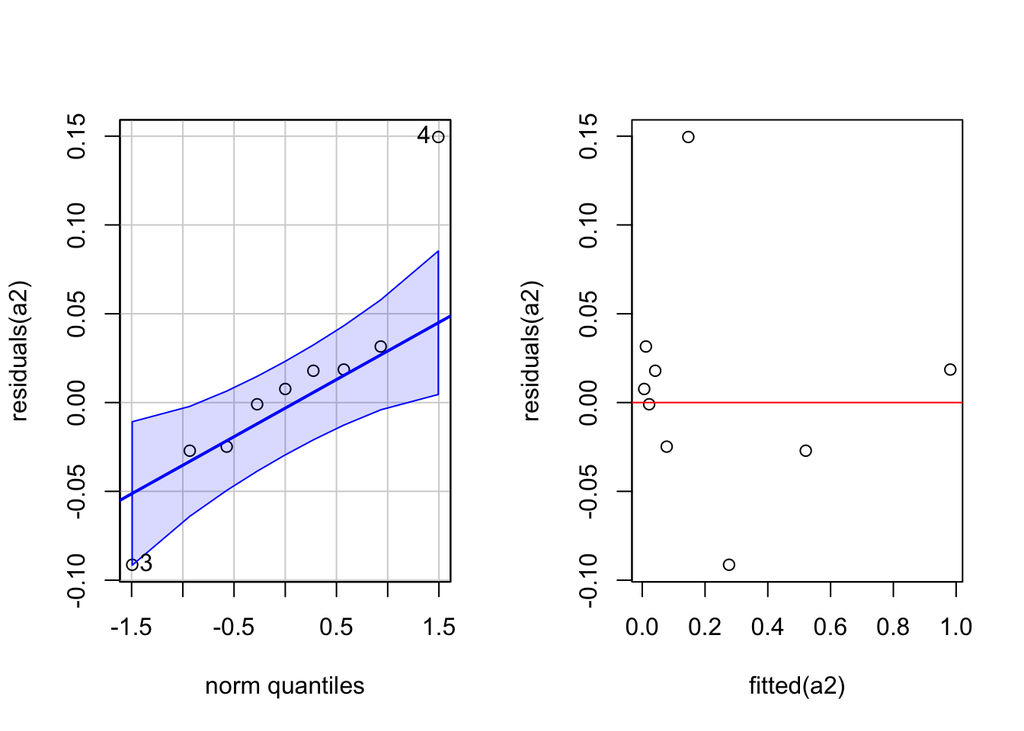

```r
### Normality of residuals
plot(residuals(a2)~fitted(a2))
abline(a=0, b=0, col="red")
```

```r
#dev.off()
```